# Logboek_Gea

Auteur: Gea Bakker  
Project: *Omics, Multi-omics analysis of thermogenic lypolysis in brown adipocytes  
Repository: https://github.com/Nikkieeex/Multi-omics_lypolysis_brown_adipocytes.git  
Wetenschappelijk artikel: https://www.sciencedirect.com/science/article/pii/S2589004225016438  
Groepsgenoten: Janine Postmus, Joris Deelstra, Nicole Bovenga

### Gebruikte tools met versies

| Tool | Versie |
| --- | --- |
| R | R version 4.5.0 (2025-04-11) |
| Rsamtools | 2.24.1 |
| dplyr | 1.1.4 |
| tidyr | 1.3.1 |
| ggplot2 | 4.0.0 |
| pheatmap | 1.0.13 |
| ggrepel | 0.9.6 |
| PCAtools | 2.20.0 |
| readxl | 1.4.5 |
| stringr | 1.6.0 |

### Logboek van Gea Bakker

Dit logboek doorloopt de handelingen die uitgevoerd zijn door Gea Bakker en toont de bijdrage voor het project. Het uiteindelijke product van dit project is een wetenschappelijk artikel waarbij de data van het bestaande wetenschappelijk artikel gebruikt is. Voor ons artikel wordt er een nieuwe onderzoeksvraag bedacht die te beantwoorden is met deze data en mogelijk extra literatuur onderzoek.

### Data inlezen en exploratieve verkenning

Voor de data verder verwerkt wordt, voer ik eerst een exploratieve data-analyse uit op de BAM-files. Hierbij lees ik de bestanden in en controleer ik de aantal reads per bestand en het aantal gemapte en ongemapte reads.

Bij een globale verkenning van de map met BAM-files viel op dat er geen bijbehorende BAI-files aanwezig waren. BAI-files zijn indexbestanden voor BAM-files en zijn nodig voor bepaalde analyses, zoals het snel opvragen van informatie per chromosoom of contig. Daarom worden de BAM-files eerst geïndexeerd voordat de verdere verkenning wordt uitgevoerd.

Nadat dit allemaal uitgevoerd is ga ik met featureCounts een count tabel maken. Hierbij worden alignments uit de BAM-files gekoppeld aan genen of features uit de annotatie. De count tabel geeft per gen weer hoeveel reads aan elk sample zijn toegewezen.

```r
indexBam(bam_files)
```

Voor de zekerheid check ik even of er voor alle BAM-files nu een BAI-file gemaakt is. Dit om te voorkomen dat er verderop in de verkenning errors ontstaan.

```r
data.frame(
  bam = basename(bam_files),
  index_exists = file.exists(paste0(bam_files, ".bai"))
)
```

```
##                                          bam index_exists
## 1  SRR32635415_Aligned.sortedByCoord.out.bam         TRUE
## 2  SRR32635416_Aligned.sortedByCoord.out.bam         TRUE
## 3  SRR32635417_Aligned.sortedByCoord.out.bam         TRUE
## 4  SRR32635418_Aligned.sortedByCoord.out.bam         TRUE
## 5  SRR32635419_Aligned.sortedByCoord.out.bam         TRUE
## 6  SRR32635420_Aligned.sortedByCoord.out.bam         TRUE
## 7  SRR32635421_Aligned.sortedByCoord.out.bam         TRUE
## 8  SRR32635422_Aligned.sortedByCoord.out.bam         TRUE
## 9  SRR32635423_Aligned.sortedByCoord.out.bam         TRUE
## 10 SRR32635424_Aligned.sortedByCoord.out.bam         TRUE
## 11 SRR32635425_Aligned.sortedByCoord.out.bam         TRUE
## 12 SRR32635426_Aligned.sortedByCoord.out.bam         TRUE
## 13 SRR32635427_Aligned.sortedByCoord.out.bam         TRUE
## 14 SRR32635428_Aligned.sortedByCoord.out.bam         TRUE
## 15 SRR32635429_Aligned.sortedByCoord.out.bam         TRUE
## 16 SRR32635430_Aligned.sortedByCoord.out.bam         TRUE
## 17 SRR32635431_Aligned.sortedByCoord.out.bam         TRUE
## 18 SRR32635432_Aligned.sortedByCoord.out.bam         TRUE
```

Nu er voor elke BAM-file een BAI-file gemaakt is, ga ik verder met de verkenning. Ik ga eerst kijken naar de total reads, mapped reads, unmapped reads en de percentage gemapte reads.

```r
bam_summary <- data.frame(
  sample = basename(bam_files),
  total_records = NA,
  mapped = NA,
  unmapped = NA,
  mapping_percentage = NA
)

for (i in seq_along(bam_files)) {
  stats <- idxstatsBam(bam_files[i])

  bam_summary$total_records[i] <- sum(stats$mapped + stats$unmapped)
  bam_summary$mapped[i] <- sum(stats$mapped)
  bam_summary$unmapped[i] <- sum(stats$unmapped)
  bam_summary$mapping_percentage[i] <- round(
    bam_summary$mapped[i] / bam_summary$total_records[i] * 100,
    2
  )
}

cat("Laagste aantal mapped reads:", min(bam_summary$mapped), "\n")
```

```
## Laagste aantal mapped reads: 40794932
```

```r
cat("Hoogste aantal mapped reads:", max(bam_summary$mapped), "\n")
```

```
## Hoogste aantal mapped reads: 135899248
```

```r
cat("Gemiddeld mapping percentage:", mean(bam_summary$mapping_percentage), "\n")
```

```
## Gemiddeld mapping percentage: 100
```

```r
cat("Aantal samples met unmapped reads:", sum(bam_summary$unmapped > 0), "\n")
```

```
## Aantal samples met unmapped reads: 0
```

Het is opvallend dat voor elk BAM-file een mapping percentage van 100% werd gevonden. Dit komt waarschijnlijk doordat alleen de gemapte alignments in de BAM-files opgenomen zijn en de ongemapte reads kunnen mogelijk weggeschreven zijn in andere outputbestanden of vermeld worden in logbestanden.

Het laagste aantal gemapte alignments is 40.794.932. Dit laat zien dat ook het kleinste bestand nog een groot aantal alignments bevat en dat de bestanden voldoende data bevatten voor verdere verwerking.

Na deze controle ga ik een count tabel maken met featureCounts. Hierbij worden de alignments uit de BAM-files gekoppeld aan genen of features uit de annotatie. De count tabel geeft per gen weer hoeveel reads aan elk sample zijn toegewezen. Deze tabel kan ik vervolgens gebruiken als basis voor de verdere exploratieve data-analyse.

De count tabel heb ik gemaakt door de onderstaande code uit te voeren in de terminal.

```bash
featureCounts -T 64 -p -a ref_genome/Mus_musculus.GRCm39.112.gtf -o counts.txt *.bam
```

Door “*.bam” te gebruiken worden alle BAM-files tot 1 count tabel verwerkt. Met de optie -a is het annotatiebestand van het referentie genoom van de muis meegegeven. De optie -o geeft aan dat de output wordt opgeslagen als counts.txt in dezelfde map waar de BAM-files in staan. Met -T 64 worden er 64 threads gebruikt om de analyse sneller uit te voeren. De optie -p geeft aan dat de data paired-end reads bevat.

Counts.txt bevat nu een count tabel waarin per gen staat hoeveel reads aan elk sample zijn toegewezen. Deze count tabel wordt vervolgens ingelezen en gebruikt voor verdere exploratieve data-analyse.

Voor de echte verkenning ga ik eerst controleren of de count tabel goed ingelezen wordt. Dit doe ik door te controleren wat de head is, de aantal kolommen en rijen en de titels van de kolommen.

```r
counts <- read.delim(
  "/students/2025-2026/Thema08/lipolyse/unpacked/transcriptomics/counts.txt",
  comment.char = "#",
  check.names = FALSE
)

str(counts)
```

```
## 'data.frame':    57186 obs. of  24 variables:
##  $ Geneid                                   : chr  "ENSMUSG00000104478" "ENSMUSG00000104385" "ENSMUSG00000101231" "ENSMUSG00000102135" ...
##  $ Chr                                      : chr  "1" "1" "1" "1;1" ...
##  $ Start                                    : chr  "108344807" "6980784" "108540067" "6986783;6993624" ...
##  $ End                                      : chr  "108347562" "6981446" "108540244" "6987219;6993812" ...
##  $ Strand                                   : chr  "+" "+" "-" "+;+" ...
##  $ Length                                   : int  2756 663 178 626 30 1869 458 325 1127 187 ...
##  $ SRR32635415_Aligned.sortedByCoord.out.bam: int  0 0 0 14 0 0 49 0 0 0 ...
##  $ SRR32635416_Aligned.sortedByCoord.out.bam: int  0 0 0 1 0 0 6 0 0 0 ...
##  $ SRR32635417_Aligned.sortedByCoord.out.bam: int  0 0 0 0 0 0 25 0 0 0 ...
##  $ SRR32635418_Aligned.sortedByCoord.out.bam: int  0 0 0 6 0 0 35 0 0 0 ...
##  $ SRR32635419_Aligned.sortedByCoord.out.bam: int  0 1 0 4 0 0 39 0 0 0 ...
##  $ SRR32635420_Aligned.sortedByCoord.out.bam: int  0 1 0 7 0 0 51 0 0 0 ...
##  $ SRR32635421_Aligned.sortedByCoord.out.bam: int  0 1 0 2 0 0 13 0 0 0 ...
##  $ SRR32635422_Aligned.sortedByCoord.out.bam: int  0 0 0 12 0 0 26 0 0 0 ...
##  $ SRR32635423_Aligned.sortedByCoord.out.bam: int  0 0 0 6 0 0 40 0 0 0 ...
##  $ SRR32635424_Aligned.sortedByCoord.out.bam: int  0 0 0 10 0 0 62 0 0 0 ...
##  $ SRR32635425_Aligned.sortedByCoord.out.bam: int  0 0 0 7 0 0 9 0 0 0 ...
##  $ SRR32635426_Aligned.sortedByCoord.out.bam: int  0 0 0 4 0 0 49 0 0 0 ...
##  $ SRR32635427_Aligned.sortedByCoord.out.bam: int  0 0 0 16 0 0 53 0 0 0 ...
##  $ SRR32635428_Aligned.sortedByCoord.out.bam: int  0 0 0 14 0 0 30 0 0 0 ...
##  $ SRR32635429_Aligned.sortedByCoord.out.bam: int  0 1 0 6 0 0 41 0 0 0 ...
##  $ SRR32635430_Aligned.sortedByCoord.out.bam: int  0 0 0 16 0 2 41 0 0 0 ...
##  $ SRR32635431_Aligned.sortedByCoord.out.bam: int  0 0 0 18 0 0 30 0 0 0 ...
##  $ SRR32635432_Aligned.sortedByCoord.out.bam: int  0 1 0 14 0 0 68 0 0 0 ...
```

De count tabel is ingelezen met read.delim(). Vervolgens is er met head() en str() gecontroleerd of de tabel correct is ingelezen. Ik krijg 57.186 features en 24 kolommen terug. De eerste kolommen bevatten geninformatie, zoals GeneID, Chr, start, end, strand en length. De rest van de kolommen bevatten de read counts per sample. Ik heb ook even gekeken naar de datatypes van de kolommen en deze zien er bruikbaar uit. De kolommen die de counts bevatten zijn integers en de kolom met de gen id is een character, dit is bruikbaar voor verdere verwerking.

Voor een snelle verwerking ga ik eerst een data frame maken met alleen de gen id en de counts per sample.

```r
gene_info <- counts[, 1:6]
count_matrix <- counts[, 7:ncol(counts)]

rownames(count_matrix) <- counts$Geneid

count_matrix <- as.data.frame(lapply(count_matrix, as.numeric))
rownames(count_matrix) <- counts$Geneid
```

Ik ga eerst kijken naar de verdeling van de counts per sample met behulp van een boxplot. Hiermee kan ik snel controleren of de samples een vergelijkbare countverdeling hebben en of er sprake is van extreme waarden of scheefheid in de data. RNA-seq countdata bevat vaak veel lage waarden en enkele zeer hoge waarden. Hierdoor verwacht ik dat de counts niet normaal verdeeld zijn.

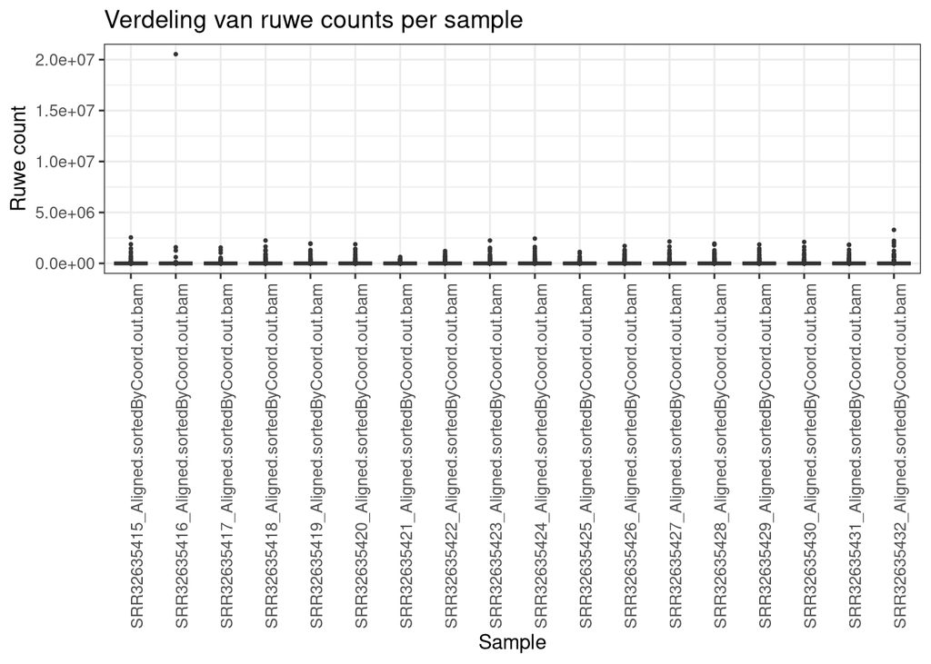

Deze boxplot laat zien dat de meeste waarden laag zijn, terwijl enkele genen extreem hoge counts hebben. Hierdoor wordt de y-as sterk beinvloed door outliers, waardoor de boxplots visueel plat gedrukt zijn. Door deze scheve verdeling zijn de samples moeilijk te vergelijken.

Deze scheve verdeling zorgt ervoor dat ik als vervolg stap een logtransformatie ga uitvoeren. De logtransformatie maakt de extreme waarden minder dominant en dat maakt de verdeling van de counts beter zichtbaar.

Omdat ik veel ‘0’ heb in mijn counts, voeg ik een +1 toe in mijn log. Dit komt er dan uit te zien als log2(count + 1). Een log uitvoeren op 0 levert ‘-Inf’ op, wat min oneindig betekent en hier kan ik niet mee verder rekenen. Log2(0 + 1) levert 0 op, dus de 0 counts worden niet beinvloed door de logtransformatie.

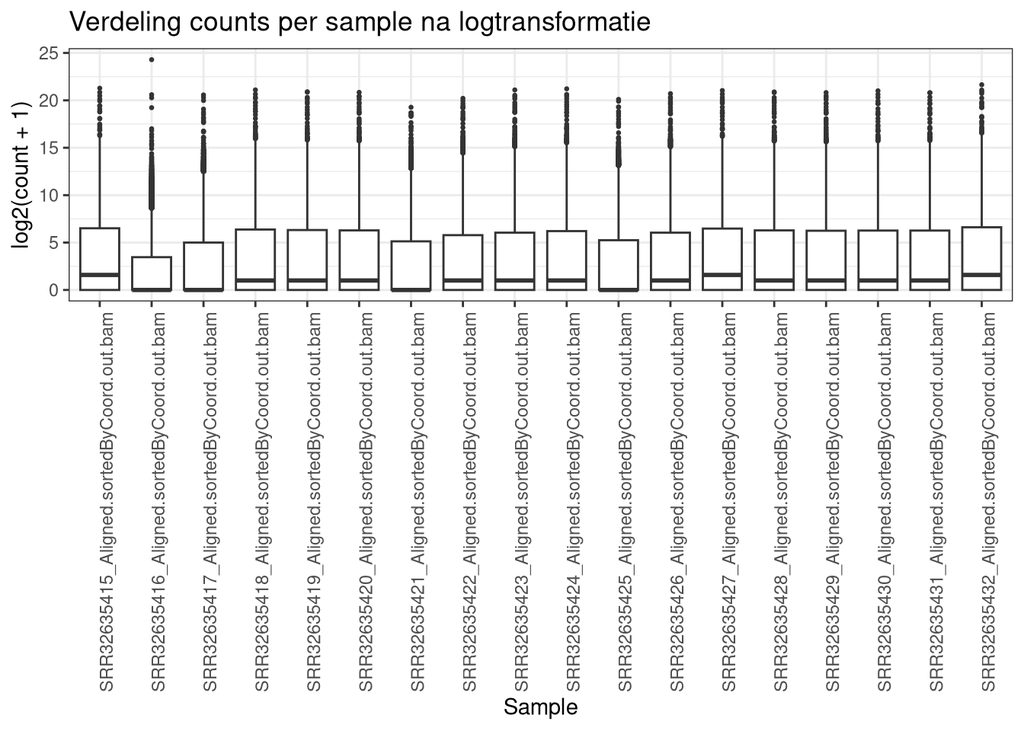

Na de logtransformatie is de verdeling van de counts per sample duidelijker zichtbaar dan zonder deze transformatie. De extreme waarden hebben minder invloed op de schaal van de y-as waardoor de boxplots beter met elkaar vergeleken kunnen worden. De meeste samples laten een vergelijkbare verdeling zien, maar er blijven outliers aanwezig. Dit is normaal bij RNA-seq countdata, omdat sommige genen veel hoger tot expressie komen dan andere genen.

De logtransformatie vermindert de scheefheid, maar corrigeert nog niet voor de verschillen in library size tussen samples. Library size geeft het totaal aantal getelde reads/fragmenten aan per sample. Dit ga ik dus doen omdat verschillen in sequencingdiepte invloed kunnen hebben op de countwaarden tussen samples.

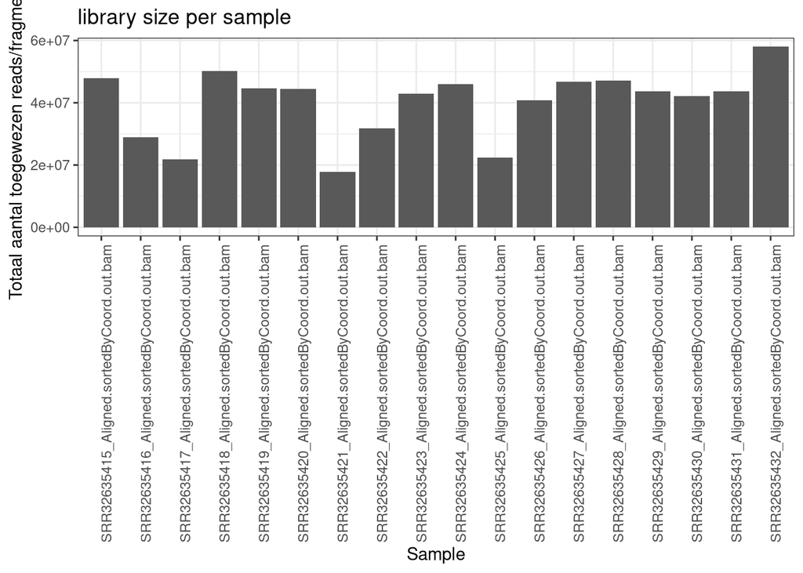

De library size is bepaald om per sample alle reads bij elkaar op te tellen. In de staafdiagram is te zien dat er grote verschillen zijn in library size tussen de samples, een aantal samples hebben 2.0e+07 reads en sommigen hebben 5.0e+07 tot 6.0e+07 reads. Dit toont aan dat het niet eerlijk is om de sample counts direct met elkaar te vergelijken. Om deze reden ga ik een normalisatie uitvoeren om te corrigeren voor deze grote verschillen.

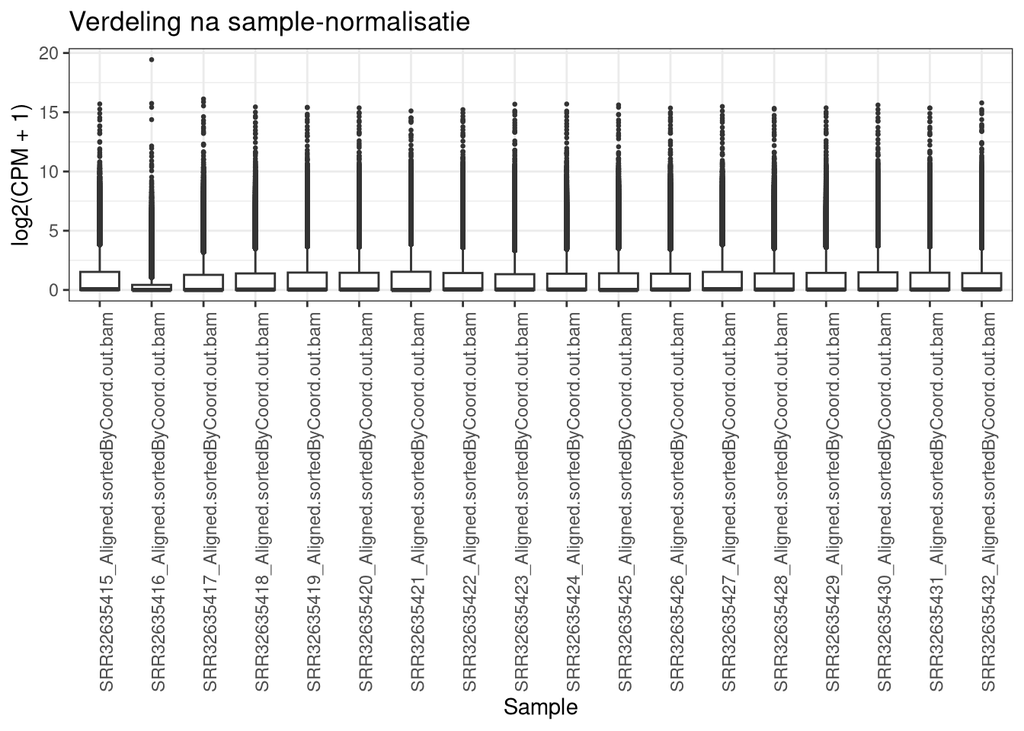

Na de sample-normalisatie, waarbij de counts per sample gedeeld is door de totale library size van dat sample, waarna het vermenigvuldigd is met 1 miljoen. Vervolgens is er nog een log transformatie uitgevoerd zodat de verdeling beter zichtbaar is.

In de boxplot na de sample-normalisatie zijn de samples beter met elkaar te vergelijken dan de ruwe counts. De verschillen in library size zijn nu gecorrigeerd, maar er zijn nog steeds outliers zichtbaar. Dit is niet te voorkomen, omdat sommige genen dusdanig meer tot expressie komen dan andere. Maar na deze normalisatie zijn de samples een stuk beter te vergelijken.

Als laatste voer ik een feature-normalisatie uit met de z-score. Hierbij wordt per gen de gemiddelde expressie afgetrokken en gedeeld door de standaarddeviatie. Hierdoor worden de waarden per gen geschaald, zodat zichtbaar wordt welke samples relatief hoge of lage waarden hebben voor een bepaald gen. Deze stap is vooral nuttig om expressiepatronen tussen samples te vergelijken.

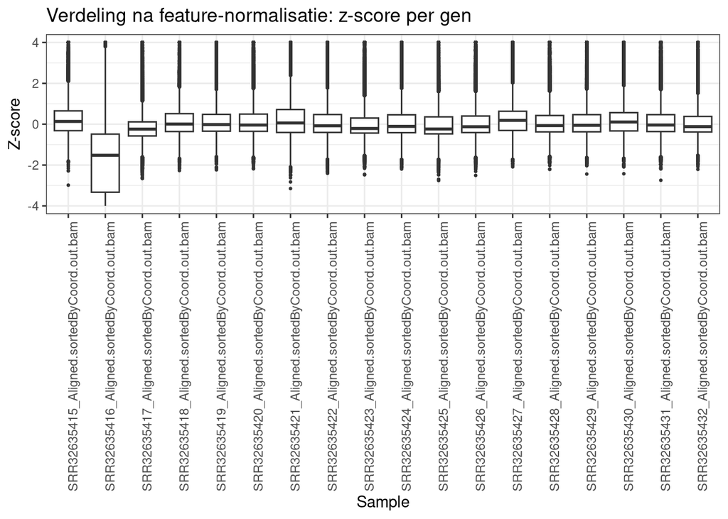

In de boxplot na de feature-normalisatie liggen de meeste samples redelijk rond een z-score van 0. De sample SRR32635416 valt duidelijk op omdat de verdeling lager ligt dan bij de andere samples. Dit betekent dat dit sample voor veel genen relatief lagere genormaliseerde waarden heeft dan de andere samples. Deze uitkomst maakt het interessant om dit sample wat uitgebreider te onderzoeken wat precies de reden is van deze afwijking.

Omdat de sample SRR32635416 zo opvallend is ga ik daar specifiek naar kijken. Ik ga een PCA uitvoeren op de getransformeerde CPM-data, waarbij dit sample specifiek gemarkeerd wordt.

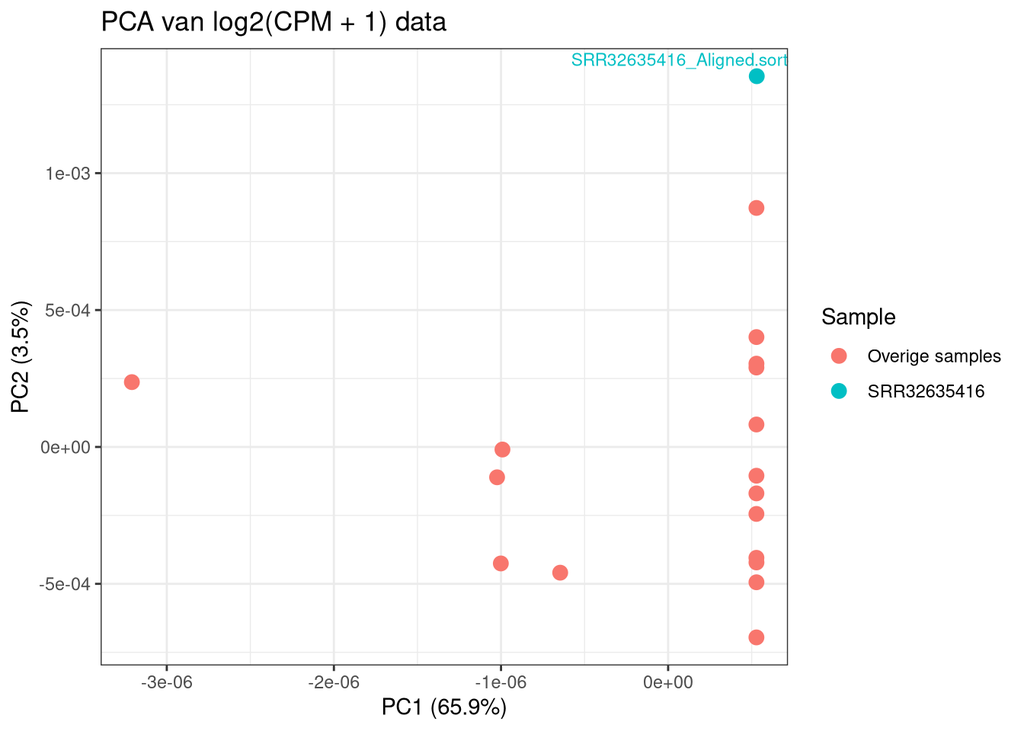

Ik ga eerst kijken welke samples precies afwijken in de PCA. Hier krijg ik de namen van de samples.

#### PCA verbetering

Deze code is tussendoor toegevoegd omdat ik deze output nodig heb voor code die ik eerder heb geschreven.

Afgelopen weekend ben ik erachter gekomen dat mijn pca elke keer verandert wanneer ik deze uitvoer. Janine heeft mij daarmee geholpen om een tool te vinden die PCA kan maken die constant blijft. Dit is gelukkig gelukt met de library PCAtools. De code heb ik uit haar logboek overgenomen omdat deze uitkomst nodig is voor een van de onderbouwingen voor de afwijkende samples. Deze samples heb ik ook gevonden bij de eerste keer dat ik de PCA heb gemaakt. Dus de onderzoek naar waarom de samples afwijken kunnen nog steeds gebruikt worden. In de code heb ik wel een aantal variabelen aangepast zodat ik geen overlap heb met de oude PCA plots.

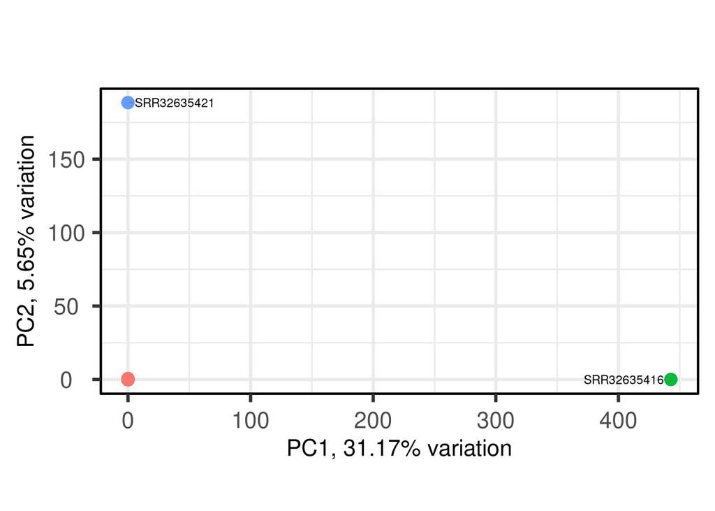

```r
pca_tools_matrix <- as.matrix(z_counts)

colnames(pca_tools_matrix) <- basename(colnames(pca_tools_matrix))

colnames(pca_tools_matrix) <- gsub(
  "_Aligned.sortedByCoord.out.bam",
  "",
  colnames(pca_tools_matrix)
)

pca_tools_metadata <- data.frame(
  sample = c(
    "SRR32635427", "SRR32635428", "SRR32635429",
    "SRR32635430", "SRR32635431", "SRR32635432",
    "SRR32635421", "SRR32635422", "SRR32635423",
    "SRR32635424", "SRR32635425", "SRR32635426",
    "SRR32635415", "SRR32635416", "SRR32635417",
    "SRR32635418", "SRR32635419", "SRR32635420"
  ),
  group = c(
    "0 h", "0 h", "0 h",
    "0 h", "0 h", "0 h",
    "4 h", "4 h", "4 h",
    "4 h", "4 h", "4 h",
    "24 h", "24 h", "24 h",
    "24 h", "24 h", "24 h"
  )
)

rownames(pca_tools_metadata) <- pca_tools_metadata$sample

pca_tools_metadata <- pca_tools_metadata[colnames(pca_tools_matrix), ]

pca_tools_result <- pca(
  mat = as.matrix(pca_tools_matrix),
  metadata = pca_tools_metadata,
  removeVar = 0.1
)

pca_tools_labels <- ifelse(
  rownames(pca_tools_metadata) %in% c("SRR32635416", "SRR32635421"),
  rownames(pca_tools_metadata),
  ""
)

biplot(
  pca_tools_result,
  colby = "group",
  lab = pca_tools_labels,
  labSize = 3
)
```

Deze PCA heeft 2 duidelijke outliers, wat mijn eerdere bevindingen bevestigt. PC1 verklaart 31.17% van de totale variatie in de dataset en PC2 verklaart 5.65%. Dit betekent dat het grootste verschil tussen de samples zichtbaar is op PC1.

```r
pca_scores <- as.data.frame(pca_tools_result$rotated)

pca_scores$sample <- rownames(pca_scores)

max_PC1 <- pca_scores[which.max(pca_scores$PC1), ]
max_PC2 <- pca_scores[which.max(pca_scores$PC2), ]

cat("Sample met de hoogste PC1-score:", max_PC1$sample, "\n")
```

```
## Sample met de hoogste PC1-score: SRR32635416
```

```r
cat("Sample met de hoogste PC2-score:", max_PC2$sample)
```

```
## Sample met de hoogste PC2-score: SRR32635421
```

Dit vertelt mij dat de sample met de hoogste PC1-score sample SRR32635416 is. De sample met de hoogste PC2-score is SRR32635421, die al eerder opviel en dit bevestigt nu dat deze sample afwijkt.

Om erachter te komen waarom deze 2 samples zo afwijkend zijn, ga ik eerst naar de counts.txt.summary kijken. Deze is samen met de count tabel gemaakt door FeatureCount.

```r
fc_summary <- read.delim(
  "/students/2025-2026/Thema08/lipolyse/unpacked/transcriptomics/counts.txt.summary",
  check.names = FALSE
)

samples_interessant <- c(
  "SRR32635416_Aligned.sortedByCoord.out.bam",
  "SRR32635421_Aligned.sortedByCoord.out.bam"
)

categorieen_interessant <- c(
  "Assigned",
  "Unassigned_MultiMapping",
  "Unassigned_NoFeatures",
  "Unassigned_Ambiguity"
)

fc_interessant_kort <- fc_summary %>%
  filter(Status %in% categorieen_interessant) %>%
  select(Status, all_of(samples_interessant))

knitr::kable(fc_interessant_kort, row.names = FALSE)
```

| Status | SRR32635416_Aligned.sortedByCoord.out.bam | SRR32635421_Aligned.sortedByCoord.out.bam |
| --- | --- | --- |
| Assigned | 28902814 | 17883374 |
| Unassigned_MultiMapping | 24995218 | 9230814 |
| Unassigned_NoFeatures | 18339330 | 12792682 |
| Unassigned_Ambiguity | 287510 | 888062 |

Dit laat zien dat SRR32635416 28902814 assigned en 43622058 unassigned reads heeft. SRR32635421 heeft 17883374 assigned en 22911558 unassigned reads. Er lijkt verschil te zitten in de assigned vs unassigned reads voor elke sample, dus ik ga voor elke sample de percentage bepalen en deze plotten, waarbij ik de 2 opvallende samples uitlicht.

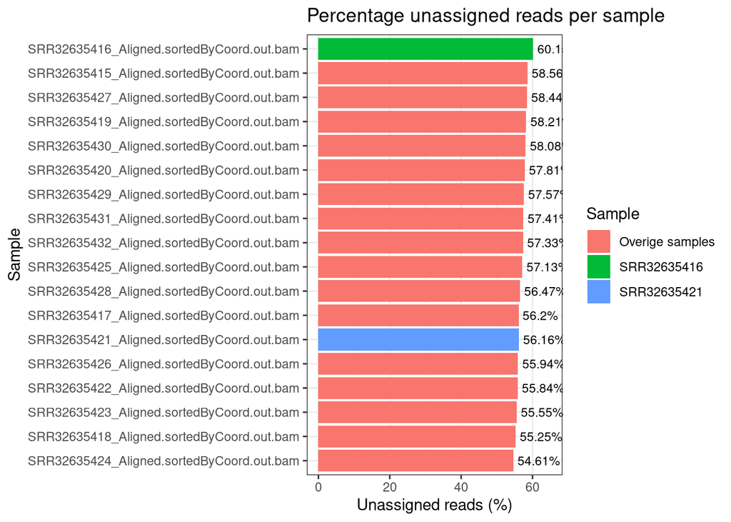

Omdat de percentage unassigned reads niks opvallends liet zien voor SRR32635421, ga ik nu kijken naar de afzonderlijke unassigned-categorieën.

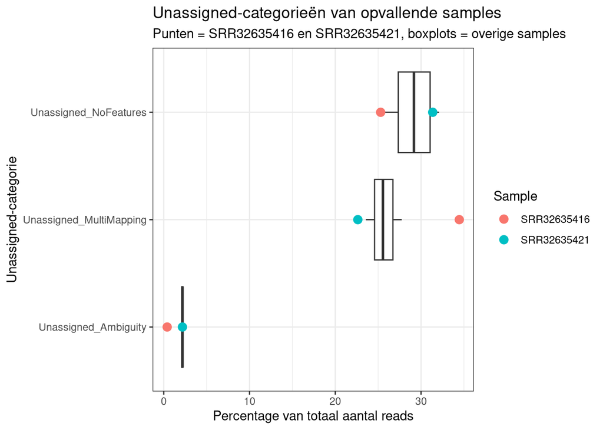

Deze plot toont aan dat er voor sample SRR32635421 nog geen duidelijke mogelijke reden is waarom deze zo afwijkt ten opzichte van de andere samples. De featureCounts-summary geeft dus geen duidelijke verklaring voor dit sample, dus er moet verder gekeken worden, bijvoorbeeld naar de aantal gedetecteerde genen per sample. Het was al duidelijk zichtbaar dat de sample SRR32635416 afweek van de overige samples, maar nu is het nog duidelijker dat het mogelijk de Unassigned_MultiMapping reads de oorzaak is van deze afwijking.

Ik kijk naar de aantal gedetecteerde genen per sample door de genen te tellen die een count hebben die hoger is dan 0. Een afwijkend laag of hoog aantal gedetecteerde genen kan wijzen op een verschil in expressieprofiel in het sample.

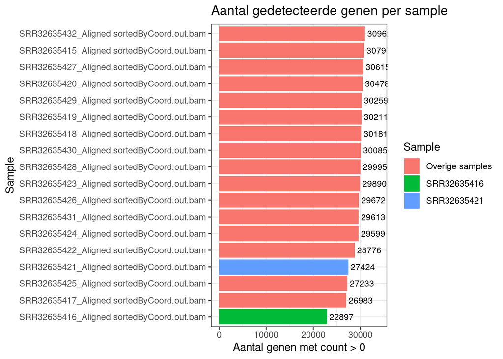

In deze grafiek is te zien dat SRR32635421 een redelijk laag aantal genen heeft met een count hoger dan 0, maar er zijn 3 samples die lager zijn, waaronder SRR32635416 die eerder al opviel. Dit is dus niet direct de oorzaak waarom sample SRR32635421 zo afwijkend is.

```r
pc1_loadings <- pca_tools_result$loadings[, 1]

names(pc1_loadings) <- rownames(pca_tools_result$loadings)

pc1_loadings <- pc1_loadings[is.finite(pc1_loadings)]

top_pc1_positive <- sort(pc1_loadings, decreasing = TRUE)[1:20]

top_pc1_negative <- sort(pc1_loadings, decreasing = FALSE)[1:20]

top_pc1_positive
```

```
## ENSMUSG00000059114 ENSMUSG00000096808 ENSMUSG00000120612 ENSMUSG00000116658
##       2.046157e-05       2.046030e-05       2.046030e-05       2.046030e-05
## ENSMUSG00000116124 ENSMUSG00000117916 ENSMUSG00000097950 ENSMUSG00000114109
##       2.046029e-05       2.046029e-05       2.046028e-05       2.045902e-05
## ENSMUSG00000117012 ENSMUSG00000021546 ENSMUSG00000035439 ENSMUSG00000007721
##       2.043854e-05       2.037133e-05       2.027642e-05       2.011903e-05
## ENSMUSG00000062014 ENSMUSG00000002910 ENSMUSG00000026887 ENSMUSG00000008333
##       2.004242e-05       2.001354e-05       1.989487e-05       1.988911e-05
## ENSMUSG00000004561 ENSMUSG00000045248 ENSMUSG00000032293 ENSMUSG00000045180
##       1.985356e-05       1.976839e-05       1.971815e-05       1.967095e-05
```

```r
top_pc1_negative
```

```
## ENSMUSG00000026312 ENSMUSG00000089697 ENSMUSG00000121902 ENSMUSG00000016308
##      -5.323316e-04      -2.044941e-05      -2.044814e-05      -2.012460e-05
## ENSMUSG00000021731 ENSMUSG00000063849 ENSMUSG00000042557 ENSMUSG00000022420
##      -2.008653e-05      -1.997748e-05      -1.995317e-05      -1.984063e-05
## ENSMUSG00000035168 ENSMUSG00000044600 ENSMUSG00000069495 ENSMUSG00000089665
##      -1.972577e-05      -1.971246e-05      -1.970929e-05      -1.958340e-05
## ENSMUSG00000031799 ENSMUSG00000026827 ENSMUSG00000090137 ENSMUSG00000031822
##      -1.948872e-05      -1.941347e-05      -1.941168e-05      -1.931109e-05
## ENSMUSG00000052794 ENSMUSG00000033020 ENSMUSG00000042303 ENSMUSG00000110393
##      -1.908296e-05      -1.906044e-05      -1.897198e-05      -1.889935e-05
```

Dit zijn de genen die het meest bijdragen aan PC1, ik ga nu kijken of deze genen erg opvallen bij SRR32635421.

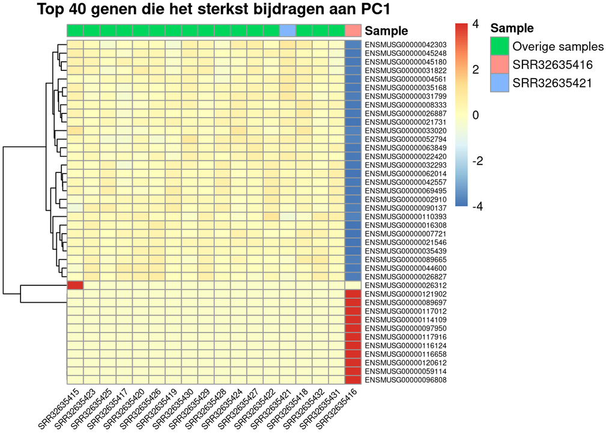

Omdat mijn PCA met de prcomp methode elke keer verandert bij het uitvoeren heb ik het op de handmatige manier geprobeerd.

```r
# Data omzetten: samples in rijen, genen/features in kolommen
P <- t(z_counts)

# PCA berekenen via de samplematrix
R <- (P %*% t(P)) / (nrow(P) - 1)
eig <- eigen(R)

# Kleine negatieve eigenwaarden door afronding op 0 zetten
eig$values[eig$values < 0] <- 0

# PCA-scores van de samples berekenen
scores <- eig$vectors %*% diag(sqrt(eig$values))

# Percentage verklaarde variantie
var_pct <- round(eig$values / sum(eig$values) * 100, 1)

# Dataframe maken voor de plot
pca_plot <- data.frame(
  sample = rownames(P),
  PC1 = scores[, 1],
  PC2 = scores[, 2]
)

# Alleen SRR-nummer uit de sample-naam halen
pca_plot$sample_id <- sub("_Aligned.*", "", pca_plot$sample)

# Tijdstip toevoegen
pca_plot$tijdstip <- dplyr::case_when(
  pca_plot$sample_id %in% c(
    "SRR32635427", "SRR32635428", "SRR32635429",
    "SRR32635430", "SRR32635431", "SRR32635432"
  ) ~ "0 h",

  pca_plot$sample_id %in% c(
    "SRR32635421", "SRR32635422", "SRR32635423",
    "SRR32635424", "SRR32635425", "SRR32635426"
  ) ~ "4 h",

  pca_plot$sample_id %in% c(
    "SRR32635415", "SRR32635416", "SRR32635417",
    "SRR32635418", "SRR32635419", "SRR32635420"
  ) ~ "24 h"
)

# PCA-plot
ggplot(pca_plot, aes(x = PC1, y = PC2, color = tijdstip)) +
  geom_point(size = 3) +
  theme_bw() +
  labs(
    title = "PCA van gestandaardiseerde transcriptomicsdata",
    x = paste0("PC1 (", var_pct[1], "%)"),
    y = paste0("PC2 (", var_pct[2], "%)"),
    color = "Tijdstip"
  )
```

Deze verandert ook elke keer. Ik ga in de groep om hulp vragen.

#### 18-05-2026

Janine heeft mij geholpen met de oplossing voor de PCA. Bij haar was deze code stabiel, dus die heb ik overgenomen en onder het kopje “PCA verbetering” gezet. De output van deze PCA heb ik nodig voor analyse over de 2 afwijkende samples die ik eerder heb gevonden.

#### 22-05-2026

In de PCA van 18-05-2026 is te zien dat SRR32635416 juist het meeste afwijkt op PC1 en sample SRR32635421 het meest afwijkt op PC2. Het bewijst nogsteeds dat deze samples afwijkend zijn, maar alleen de heatmap op de genen die het meeste invloed hebben op PC1 wijst voor de sample SRR32635421 niks meer uit. Om deze reden voer ik het nog even snel op de genen die het meeste invloed hebben op PC2 uit, en dit vergelijk ik dan met de heatmap van de top 40 van de PC1 genen.

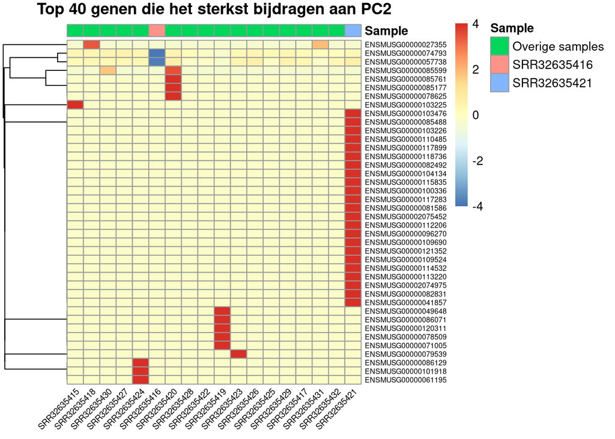

Deze heatmap samen met de heatmap van de top 40 genen die het sterkst bijdragen aan PC1 geeft een duidelijke reden waarom sample SRR32635416 en SRR32635421 afwijken van de andere samples.

#### 26-05-2026

Vandaag maak ik de matrix zodat Joris de MOFA+ tool kan gebruiken. Voor uitleg over deze tool verwijs ik u graag naar zijn logboek.

```r
transcriptomics_matrix <- as.matrix(z_counts)
mode(transcriptomics_matrix) <- "numeric"

colnames(transcriptomics_matrix) <- basename(colnames(transcriptomics_matrix))

colnames(transcriptomics_matrix) <- gsub(
  "_Aligned.sortedByCoord.out.bam",
  "",
  colnames(transcriptomics_matrix)
)
```

```r
write.csv(
  transcriptomics_matrix,
  "/students/2025-2026/Thema08/lipolyse/unpacked/transcriptomics/transcriptomics_matrix.csv"
)
```

| Controle | Waarde |
| --- | --- |
| Aantal genen/features | 41106 |
| Aantal samples | 18 |
| Aantal NA-waarden | 0 |
| Aantal NaN-waarden | 0 |
| Aantal Inf-waarden | 0 |
| Objectklasse | matrix, array |
| Datamodus | numeric |

De feature matrix is nu gemaakt. Ik heb hiervoor de volledig genormaliseerde count data gebruikt die ik gemaakt heb bij mijn EDA. In de matrix heb ik de samples als kolommen en de features/genen als rijen opgeslagen. Tijdens het normaliseren ben ik een aantal features kwijt geraakt, dit zijn mogelijk genen die over elke sample dezelfde waarde heeft. Verder is ook te zien dat mijn matrix geen NA-, NaN-, of Inf-waarden bevatten. Dit betekent dat er geen waarden zijn die problemen gaan veroorzaken bij de verdere MOFA+-analyse.

#### 01-06-2026

Joris is bezig gegaan met het runnen van MOFA+. Dit is helaas niet gelukt. Daarom is afgelopen vrijdag (29-05-2026), in overleg met Marcel, een nieuw plan bedacht. Omdat MOFA+ niet succesvol kon worden uitgevoerd, is er gekozen om de transcriptomics- en proteomicsresultaten eerst apart te analyseren en daarna met elkaar te vergelijken.

Joris gaat DEG-lijsten maken van de transcriptomics, daarbij maakt hij een Venn-diagram en maakt een top 10 of 15 van de meest interessante genen. Nicole maakt de DAP-lijsten van de proteomics en maakt vervolgens een overlap lijst met de DAP-lijsten en DEG-lijsten. Ik ga me focussen op het uitvoeren van Metascape op de DEG- en DAP-lijsten, maak daaruit een top 15 van de overlappende genen/eiwitten en daaruit maak ik een aantal plotjes die in het artikel gebruikt kunnen worden. Janine gaat aan de hand van die top 15 overlappende genen/eiwitten opzoeken wat ze precies doen.

Metascape is een webgebaseerde tool voor genlijst-annotatie en enrichment-analyse. Hiermee kunnen ingevoerde gen- of eiwitlijsten worden gekoppeld aan biologische processen, pathways en eiwitnetwerken. Deze tool is nuttig voor ons omdat de DEG- en DAP-lijsten op zichzelf aangeven welke genen of eiwitten significant veranderen, maar nog niet direct laten zien welke biologische processen hierbij betrokken worden. In dit project wordt Metascape daarom gebruikt om per DEG- en DAP-lijst de belangrijkste verrijkte pathways te bepalen en deze te vergelijken tussen de transcriptomics en proteomics.

Ik heb de DAP-lijsten al binnengehaald van de git-repository, dus deze ga ik eerst inlezen en controleren of het goed ingelezen wordt en controleren of er geen missende waarden aanwezig zijn.

```r
dap_all <- read.csv("../DAP_lists/All_DAPs_combined.csv")
```

| Controle | Waarde |
| --- | --- |
| Aantal rijen | 13203 |
| Aantal kolommen | 5 |
| Aantal missende waarden | 0 |
| Aantal lege cellen | 0 |

De kolomnamen zijn zoals ik het heb verwacht, tijdens het overleg is er afgesproken dat in de DAP lijsten de gen ID, logFC, p-waarde en de aangepaste p-waarde geleverd zouden worden. Ik heb hier ook nog een kolom met ‘comparison’, deze kolom geeft aan uit welke tijdsvergelijking de DAP afkomstig is. Ook heb ik geen missende waarden of lege cellen in deze dataset.

#### 02-06-2026

Ik heb ondertussen ook de DEG-lijsten gekregen van Joris, deze ga ik net als de DAP-lijsten bekijken en ik wil van beide nog even de statistsiche waarden bekijken om te bevestigen dat ze op dezelfde manier gefilterd zijn.

```r
deg_ab <- read.csv("/students/2025-2026/Thema08/lipolyse/unpacked/transcriptomics/significant_DEG_AB_rna.csv")

deg_ac <- read.csv("/students/2025-2026/Thema08/lipolyse/unpacked/transcriptomics/significant_DEG_AC_rna.csv")

deg_bc <- read.csv("/students/2025-2026/Thema08/lipolyse/unpacked/transcriptomics/significant_DEG_BC_rna.csv")

deg_4h_vs_0h <- deg_ab
deg_24h_vs_0h <- deg_ac
deg_24h_vs_4h <- deg_bc
```

| Vergelijking | Aantal_rijen | Aantal_kolommen | Aantal_missende_waarden | Aantal_lege_cellen |
| --- | --- | --- | --- | --- |
| 4h_vs_0h | 9997 | 7 | 0 | 0 |
| 24h_vs_0h | 11587 | 7 | 0 | 0 |
| 24h_vs_4h | 11603 | 7 | 0 | 0 |

In deze controle is te zien dat er geen missende waarden en lege cellen zijn. Ik heb 7 kolommen, zoals verwacht dus ik ga nu verder met de statistieke beoordeling van DEG- en DAP-lijsten.

```r
deg_stat_controle <- data.frame(
  Vergelijking = c("4h_vs_0h", "24h_vs_0h", "24h_vs_4h"),

  Aantal_DEGs = c(
    nrow(deg_4h_vs_0h),
    nrow(deg_24h_vs_0h),
    nrow(deg_24h_vs_4h)
  ),

  Min_padj = c(
    min(deg_4h_vs_0h$padj, na.rm = TRUE),
    min(deg_24h_vs_0h$padj, na.rm = TRUE),
    min(deg_24h_vs_4h$padj, na.rm = TRUE)
  ),

  Max_padj = c(
    max(deg_4h_vs_0h$padj, na.rm = TRUE),
    max(deg_24h_vs_0h$padj, na.rm = TRUE),
    max(deg_24h_vs_4h$padj, na.rm = TRUE)
  ),

  Aantal_padj_boven_0.05 = c(
    sum(deg_4h_vs_0h$padj >= 0.05, na.rm = TRUE),
    sum(deg_24h_vs_0h$padj >= 0.05, na.rm = TRUE),
    sum(deg_24h_vs_4h$padj >= 0.05, na.rm = TRUE)
  ),

  Upregulated = c(
    sum(deg_4h_vs_0h$log2FoldChange > 0, na.rm = TRUE),
    sum(deg_24h_vs_0h$log2FoldChange > 0, na.rm = TRUE),
    sum(deg_24h_vs_4h$log2FoldChange > 0, na.rm = TRUE)
  ),

  Downregulated = c(
    sum(deg_4h_vs_0h$log2FoldChange < 0, na.rm = TRUE),
    sum(deg_24h_vs_0h$log2FoldChange < 0, na.rm = TRUE),
    sum(deg_24h_vs_4h$log2FoldChange < 0, na.rm = TRUE)
  ),

  Min_log2FC = c(
    min(deg_4h_vs_0h$log2FoldChange, na.rm = TRUE),
    min(deg_24h_vs_0h$log2FoldChange, na.rm = TRUE),
    min(deg_24h_vs_4h$log2FoldChange, na.rm = TRUE)
  ),

  Mediaan_log2FC = c(
    median(deg_4h_vs_0h$log2FoldChange, na.rm = TRUE),
    median(deg_24h_vs_0h$log2FoldChange, na.rm = TRUE),
    median(deg_24h_vs_4h$log2FoldChange, na.rm = TRUE)
  ),

  Max_log2FC = c(
    max(deg_4h_vs_0h$log2FoldChange, na.rm = TRUE),
    max(deg_24h_vs_0h$log2FoldChange, na.rm = TRUE),
    max(deg_24h_vs_4h$log2FoldChange, na.rm = TRUE)
  )
)

knitr::kable(deg_stat_controle, row.names = FALSE, digits = 4)
```

| Vergelijking | Aantal_DEGs | Min_padj | Max_padj | Aantal_padj_boven_0.05 | Upregulated | Downregulated | Min_log2FC | Mediaan_log2FC | Max_log2FC |
| --- | --- | --- | --- | --- | --- | --- | --- | --- | --- |
| 4h_vs_0h | 9997 | 0 | 0.05 | 0 | 4924 | 5073 | -5.4802 | -0.1077 | 4.7213 |
| 24h_vs_0h | 11587 | 0 | 0.05 | 0 | 5685 | 5902 | -7.6274 | -0.1084 | 4.7778 |
| 24h_vs_4h | 11603 | 0 | 0.05 | 0 | 5712 | 5891 | -6.5450 | -0.1107 | 5.5427 |

| Vergelijking | Aantal_DAPs | Min_adj_P_Val | Max_adj_P_Val | Aantal_adj_P_Val_boven_0.05 | Upregulated | Downregulated | Min_logFC | Mediaan_logFC | Max_logFC |
| --- | --- | --- | --- | --- | --- | --- | --- | --- | --- |
| 4h_vs_0h | 4401 | 0 | 1 | 4133 | 1865 | 1481 | -5.8285 | 0 | 4.7917 |
| 24h_vs_0h | 4401 | 0 | 1 | 3402 | 1865 | 1481 | -5.8285 | 0 | 4.7917 |
| 24h_vs_4h | 4401 | 0 | 1 | 3438 | 2028 | 1330 | -3.4493 | 0 | 4.0139 |

De statistische toetsen vertellen mij dat de DEG-lijsten wel gefilterd zijn op padj <0.05, maar de DAP-lijsten zijn niet gefilterd op de padj <0.05. Deze filter ga ik nog even toepassen en de output ga ik dan wegschrijven. De log fold change is niet gefilterd, misschien dat er met die filter teveel data verloren gaat. Ik ga dus eerst de lijsten proberen die op padj<0.05 gefilterd zijn in Metascape, als die data teveel is ga ik de log fold change filteren.

```r
write.csv(
  dap_4h_vs_0h_sig, "/students/2025-2026/Thema08/lipolyse/unpacked/proteomics/significant_DAP_4h_vs_0h.csv", row.names = FALSE
)

write.csv(
  dap_24h_vs_0h_sig, "/students/2025-2026/Thema08/lipolyse/unpacked/proteomics/significant_DAP_24h_vs_0h.csv", row.names = FALSE
)

write.csv(
  dap_24h_vs_4h_sig, "/students/2025-2026/Thema08/lipolyse/unpacked/proteomics/significant_DAP_24h_vs_4h.csv", row.names = FALSE
)
```

| Vergelijking | Voor_filtering | Na_filtering | Max_adj_P_Val_na_filtering |
| --- | --- | --- | --- |
| 4h_vs_0h | 4401 | 268 | 0.0495 |
| 24h_vs_0h | 4401 | 999 | 0.0494 |
| 24h_vs_4h | 4401 | 963 | 0.0499 |

Na het toepassen van de filter padj <0.05 is te zien dat er aanzienlijk minder rijen aanwezig zijn in de DAP-lijsten. Aan de max_adj_P_val_na_filtering is te zien dat er goed gefilterd is. De gefilterde DAP- en DEG-lijsten ga ik uploaden naar Metascape per groep en met die uitkomst ga ik verder werken.

Voor Metascape moet ik per groep 1 bestand maken waarbij de DAP-genen en de DEG-genen per kolom in staan.

```r
make_metascape_file <- function(dap_genes, deg_genes, output_file) {

  dap_genes <- unique(na.omit(dap_genes))
  deg_genes <- unique(na.omit(deg_genes))

  max_length <- max(length(dap_genes), length(deg_genes))

  dap_genes <- c(dap_genes, rep(NA, max_length - length(dap_genes)))
  deg_genes <- c(deg_genes, rep(NA, max_length - length(deg_genes)))

  metascape_input <- data.frame(
    DAP = dap_genes,
    DEG = deg_genes
  )

  write.csv(
    metascape_input,
    output_file,
    row.names = FALSE,
    quote = FALSE,
    na = ""
  )
}

make_metascape_file(
  dap_genes = dap_4h_vs_0h_sig$ensembl_gene_id,
  deg_genes = deg_4h_vs_0h$Gene,
  output_file = "/students/2025-2026/Thema08/lipolyse/unpacked/Metascape_input/Metascape_4h_vs_0h.csv"
)

make_metascape_file(
  dap_genes = dap_24h_vs_0h_sig$ensembl_gene_id,
  deg_genes = deg_24h_vs_0h$Gene,
  output_file = "/students/2025-2026/Thema08/lipolyse/unpacked/Metascape_input/Metascape_24h_vs_0h.csv"
)

make_metascape_file(
  dap_genes = dap_24h_vs_4h_sig$ensembl_gene_id,
  deg_genes = deg_24h_vs_4h$Gene,
  output_file = "/students/2025-2026/Thema08/lipolyse/unpacked/Metascape_input/Metascape_24h_vs_4h.csv"
)
```

```r
metalijst_4h_vs_0h <- read.csv("/students/2025-2026/Thema08/lipolyse/unpacked/Metascape_input/Metascape_4h_vs_0h.csv")
metalijst_24h_vs_0h <- read.csv("/students/2025-2026/Thema08/lipolyse/unpacked/Metascape_input/Metascape_24h_vs_0h.csv")
metalijst_24h_vs_4h <- read.csv("/students/2025-2026/Thema08/lipolyse/unpacked/Metascape_input/Metascape_24h_vs_4h.csv")

head(metalijst_4h_vs_0h)
```

```
##                  DAP                DEG
## 1 ENSMUSG00000032786 ENSMUSG00000051285
## 2 ENSMUSG00000021794 ENSMUSG00000039748
## 3 ENSMUSG00000025134 ENSMUSG00000057363
## 4 ENSMUSG00000024742 ENSMUSG00000100555
## 5 ENSMUSG00000066551 ENSMUSG00000103411
## 6 ENSMUSG00000037742 ENSMUSG00000102030
```

```r
head(metalijst_24h_vs_0h)
```

```
##                  DAP                DEG
## 1 ENSMUSG00000032557 ENSMUSG00000051285
## 2 ENSMUSG00000032786 ENSMUSG00000048538
## 3 ENSMUSG00000019577 ENSMUSG00000097797
## 4 ENSMUSG00000022607 ENSMUSG00000057363
## 5 ENSMUSG00000025001 ENSMUSG00000100555
## 6 ENSMUSG00000030681 ENSMUSG00000038702
```

```r
head(metalijst_24h_vs_4h)
```

```
##                  DAP                DEG
## 1 ENSMUSG00000032557 ENSMUSG00000100764
## 2 ENSMUSG00000022607 ENSMUSG00000039748
## 3 ENSMUSG00000029545 ENSMUSG00000057363
## 4 ENSMUSG00000030605 ENSMUSG00000090243
## 5 ENSMUSG00000061838 ENSMUSG00000038702
## 6 ENSMUSG00000035284 ENSMUSG00000061024
```

De lijsten zijn goed gemaakt, dus ik ga metascape uitvoeren op de website. Deze lijsten pakt Metascape perfect, dus ik ga niet verder filteren op de log fold change.

Metascape is nu uitgevoerd, ik heb de resultaten opgeslagen en alvast kort bekeken. Het viel me op dat er veel housekeeping pathways in zitten. Housekeeping pathways hebben te maken met algemene cellulaire processen en zijn niet direct specifiek voor lipolyse. Hier ga ik morgen mee verder om te kijken of deze eruit gehaald kunnen worden zodat we alleen de pathways hebben waarin we geïnteresseerd zijn.

#### 03-06-2026

Gisteren heb ik de Metascape gerund en die resultaten opgeslagen. Ik ga nu kijken of ik de housekeeping pathways kan filteren. Het doel hiervan is om de uiteindelijke grafieken vooral pathways te tonen die inhoudelijk relevant zijn voor lipolyse, vetzuurmetabolisme, mitochondriale activiteit en thermogenese. Ik heb specifiek voor deze pathways gekozen omdat deze processen gelinkt zijn aan lipolyse.

```r
metascape_4h_vs_0h <- read_excel(
  "/students/2025-2026/Thema08/lipolyse/unpacked/Metascape_output/comparison_4h_vs_0h/metascape_result_4hvs0h.xlsx",
  sheet = "Enrichment"
)

metascape_24h_vs_0h <- read_excel(
  "/students/2025-2026/Thema08/lipolyse/unpacked/Metascape_output/comparison_24h_vs_0h/metascape_result_24hvs0h.xlsx",
  sheet = "Enrichment"
)

metascape_24h_vs_4h <- read_excel(
  "/students/2025-2026/Thema08/lipolyse/unpacked/Metascape_output/comparison_24h_vs_4h/metascape_result_24hvs4h.xlsx",
  sheet = "Enrichment"
)
```

```r
metascape_controle <- data.frame(
  Vergelijking = c("4h_vs_0h", "24h_vs_0h", "24h_vs_4h"),
  Aantal_rijen = c(
    nrow(metascape_4h_vs_0h),
    nrow(metascape_24h_vs_0h),
    nrow(metascape_24h_vs_4h)
  ),
  Aantal_kolommen = c(
    ncol(metascape_4h_vs_0h),
    ncol(metascape_24h_vs_0h),
    ncol(metascape_24h_vs_4h)
  ),
  Kolomnamen = c(
    paste(colnames(metascape_4h_vs_0h), collapse = ", "),
    paste(colnames(metascape_24h_vs_0h), collapse = ", "),
    paste(colnames(metascape_24h_vs_4h), collapse = ", ")
  )
)

knitr::kable(metascape_controle, row.names = FALSE)
```

| Vergelijking | Aantal_rijen | Aantal_kolommen | Kolomnamen |
| --- | --- | --- | --- |
| 4h_vs_0h | 501 | 9 | GroupID, Category, Term, Description, LogP, Log(q-value), Genes, Symbols, InTerm_InList |
| 24h_vs_0h | 428 | 9 | GroupID, Category, Term, Description, LogP, Log(q-value), Genes, Symbols, InTerm_InList |
| 24h_vs_4h | 374 | 9 | GroupID, Category, Term, Description, LogP, Log(q-value), Genes, Symbols, InTerm_InList |

Ik heb een controle uitgevoerd of het goed ingelezen is omdat ik nog nooit met meerdere tabbladen in een excel bestand heb gewerkt. Het aantal kolommen en de kolomnamen vertellen mij dat het goed is ingelezen. Ik heb eerst groupID nodig om te filteren, en even later heb ik ook de Log(q-value) nodig.

In Metascape worden de pathways geclusterd en er bestaat veel overlap in de termen die Metascape geeft. Daarom ga ik eerst op ‘summary’ filteren. Ook deze ga ik weer controleren om te kijken of alle summaries apart worden opgeslagen.

```r
metascape_summary_4h_vs_0h <- metascape_4h_vs_0h %>%
  filter(grepl("Summary", GroupID))

metascape_summary_24h_vs_0h <- metascape_24h_vs_0h %>%
  filter(grepl("Summary", GroupID))

metascape_summary_24h_vs_4h <- metascape_24h_vs_4h %>%
  filter(grepl("Summary", GroupID))
```

```r
summary_controle <- data.frame(
  Vergelijking = c("4h_vs_0h", "24h_vs_0h", "24h_vs_4h"),
  Aantal_termen_totaal = c(
    nrow(metascape_4h_vs_0h),
    nrow(metascape_24h_vs_0h),
    nrow(metascape_24h_vs_4h)
  ),
  Aantal_summary_termen = c(
    nrow(metascape_summary_4h_vs_0h),
    nrow(metascape_summary_24h_vs_0h),
    nrow(metascape_summary_24h_vs_4h)
  )
)

knitr::kable(summary_controle, row.names = FALSE)
```

| Vergelijking | Aantal_termen_totaal | Aantal_summary_termen |
| --- | --- | --- |
| 4h_vs_0h | 501 | 20 |
| 24h_vs_0h | 428 | 20 |
| 24h_vs_4h | 374 | 20 |

Na het filteren op summary is te zien dat er voor elke vergelijking 20 summaries aanwezig zijn.

Nu deze opgeslagen zijn, ga ik eerst relevante en housekeeping zoektermen opslaan. Dit doe ik om het filteren straks gemakkelijker te maken.

```r
relevante_termen <- c(
  "lipid",
  "lipolysis",
  "fatty acid",
  "fatty acid oxidation",
  "beta-oxidation",
  "PPAR",
  "adip",
  "thermogenesis",
  "mitochond",
  "oxidative phosphorylation",
  "electron transport",
  "TCA",
  "tricarboxylic",
  "cholesterol",
  "peroxisome"
)

housekeeping_termen <- c(
  "ribosome",
  "translation",
  "rRNA",
  "RNA processing",
  "spliceosome",
  "protein folding",
  "proteasome",
  "cell cycle",
  "DNA replication",
  "mitotic",
  "chromosome",
  "nucleotide",
  "purine",
  "pyrimidine",
  "amino acid biosynthesis"
)
```

Voor ik alle housekeeping pathways ga verwijderen, wil ik eerst kijken hoeveel housekeeping pathways en lipolyse gerelateerde pathways aanwezig zijn. Dit doe ik door te markeren en daarna voer ik weer een controle stap uit die kijkt hoeveel er van elk is.

```r
metascape_summary_4h_vs_0h <- metascape_summary_4h_vs_0h %>%
  mutate(
    relevant_lipolyse = grepl(
      paste(relevante_termen, collapse = "|"),
      Description,
      ignore.case = TRUE
    ),
    housekeeping = grepl(
      paste(housekeeping_termen, collapse = "|"),
      Description,
      ignore.case = TRUE
    )
  )

metascape_summary_24h_vs_0h <- metascape_summary_24h_vs_0h %>%
  mutate(
    relevant_lipolyse = grepl(
      paste(relevante_termen, collapse = "|"),
      Description,
      ignore.case = TRUE
    ),
    housekeeping = grepl(
      paste(housekeeping_termen, collapse = "|"),
      Description,
      ignore.case = TRUE
    )
  )

metascape_summary_24h_vs_4h <- metascape_summary_24h_vs_4h %>%
  mutate(
    relevant_lipolyse = grepl(
      paste(relevante_termen, collapse = "|"),
      Description,
      ignore.case = TRUE
    ),
    housekeeping = grepl(
      paste(housekeeping_termen, collapse = "|"),
      Description,
      ignore.case = TRUE
    )
  )
```

```r
filter_controle <- data.frame(
  Vergelijking = c("4h_vs_0h", "24h_vs_0h", "24h_vs_4h"),

  Summary_termen = c(
    nrow(metascape_summary_4h_vs_0h),
    nrow(metascape_summary_24h_vs_0h),
    nrow(metascape_summary_24h_vs_4h)
  ),

  Relevante_lipolyse_termen = c(
    sum(metascape_summary_4h_vs_0h$relevant_lipolyse),
    sum(metascape_summary_24h_vs_0h$relevant_lipolyse),
    sum(metascape_summary_24h_vs_4h$relevant_lipolyse)
  ),

  Housekeeping_termen = c(
    sum(metascape_summary_4h_vs_0h$housekeeping),
    sum(metascape_summary_24h_vs_0h$housekeeping),
    sum(metascape_summary_24h_vs_4h$housekeeping)
  )
)

knitr::kable(filter_controle, row.names = FALSE)
```

| Vergelijking | Summary_termen | Relevante_lipolyse_termen | Housekeeping_termen |
| --- | --- | --- | --- |
| 4h_vs_0h | 20 | 3 | 1 |
| 24h_vs_0h | 20 | 2 | 5 |
| 24h_vs_4h | 20 | 2 | 3 |

Ik had verwacht dat de 20 in ieder geval verdeeld zouden worden over de lipolyse termen en housekeeping termen. Ik ga eerst even kijken naar de relevante termen en daarna kan ik nog beslissen of ik de relevante termen wil aanpassen.

```r
relevante_metascape_termen <- bind_rows(
  metascape_summary_4h_vs_0h %>%
    filter(relevant_lipolyse == TRUE) %>%
    mutate(Vergelijking = "4h_vs_0h"),

  metascape_summary_24h_vs_0h %>%
    filter(relevant_lipolyse == TRUE) %>%
    mutate(Vergelijking = "24h_vs_0h"),

  metascape_summary_24h_vs_4h %>%
    filter(relevant_lipolyse == TRUE) %>%
    mutate(Vergelijking = "24h_vs_4h")
)

relevante_metascape_termen <- relevante_metascape_termen %>%
  select(
    Vergelijking,
    Category,
    Description,
    LogP,
    `Log(q-value)`
  ) %>%
  arrange(Vergelijking, `Log(q-value)`)

knitr::kable(relevante_metascape_termen, row.names = FALSE, digits = 3)
```

| Vergelijking | Category | Description | LogP | Log(q-value) |
| --- | --- | --- | --- | --- |
| 24h_vs_0h | Reactome Gene Sets | Mitochondrial protein degradation | -19.236 | -16.960 |
| 24h_vs_0h | GO Biological Processes | mitochondrial translation | -16.779 | -14.657 |
| 24h_vs_4h | Reactome Gene Sets | Mitochondrial protein degradation | -32.307 | -29.262 |
| 24h_vs_4h | GO Biological Processes | mitochondrial gene expression | -18.459 | -16.422 |
| 4h_vs_0h | Reactome Gene Sets | Mitochondrial protein degradation | -16.548 | -13.144 |
| 4h_vs_0h | KEGG Pathway | Citrate cycle (TCA cycle) - Mus musculus (house mouse) | -9.992 | -7.612 |
| 4h_vs_0h | GO Biological Processes | establishment of protein localization to mitochondrion | -9.361 | -7.026 |

Dit zijn niet de pathways die direct betrokken zijn bij de lipolyse. Ik ga nu alle pathways bekijken die onder summary vallen en kijken of daar interessante pathways tussen zitten. Mochten die aanwezig zijn, dan breidt ik de lijst uit.

```r
summary_terms_all <- bind_rows(
  metascape_summary_4h_vs_0h %>%
    mutate(Vergelijking = "4h_vs_0h"),
  metascape_summary_24h_vs_0h %>%
    mutate(Vergelijking = "24h_vs_0h"),
  metascape_summary_24h_vs_4h %>%
    mutate(Vergelijking = "24h_vs_4h")
) %>%
  select(
    Vergelijking,
    Category,
    Description,
    LogP,
    `Log(q-value)`,
    relevant_lipolyse,
    housekeeping
  ) %>%
  arrange(Vergelijking, `Log(q-value)`)

knitr::kable(summary_terms_all, row.names = FALSE, digits = 3)
```

| Vergelijking | Category | Description | LogP | Log(q-value) | relevant_lipolyse | housekeeping |
| --- | --- | --- | --- | --- | --- | --- |
| 24h_vs_0h | Reactome Gene Sets | Translation | -69.889 | -65.640 | FALSE | TRUE |
| 24h_vs_0h | Reactome Gene Sets | Metabolism of RNA | -56.338 | -52.690 | FALSE | FALSE |
| 24h_vs_0h | GO Biological Processes | nucleobase-containing small molecule metabolic process | -35.044 | -31.494 | FALSE | FALSE |
| 24h_vs_0h | Reactome Gene Sets | Ribosome-associated quality control | -33.337 | -30.042 | FALSE | TRUE |
| 24h_vs_0h | KEGG Pathway | Carbon metabolism - Mus musculus (house mouse) | -30.850 | -27.747 | FALSE | FALSE |
| 24h_vs_0h | GO Biological Processes | small molecule biosynthetic process | -25.055 | -22.268 | FALSE | FALSE |
| 24h_vs_0h | GO Biological Processes | small molecule catabolic process | -23.687 | -21.051 | FALSE | FALSE |
| 24h_vs_0h | GO Biological Processes | amino acid metabolic process | -23.440 | -20.863 | FALSE | FALSE |
| 24h_vs_0h | WikiPathways | Translation factors | -23.268 | -20.709 | FALSE | TRUE |
| 24h_vs_0h | WikiPathways | Amino acid metabolism | -20.136 | -17.817 | FALSE | FALSE |
| 24h_vs_0h | Reactome Gene Sets | Mitochondrial protein degradation | -19.236 | -16.960 | TRUE | FALSE |
| 24h_vs_0h | GO Biological Processes | tRNA aminoacylation | -19.206 | -16.935 | FALSE | FALSE |
| 24h_vs_0h | GO Biological Processes | regulation of translation | -18.894 | -16.659 | FALSE | TRUE |
| 24h_vs_0h | Reactome Gene Sets | Neutrophil degranulation | -17.795 | -15.628 | FALSE | FALSE |
| 24h_vs_0h | GO Biological Processes | mitochondrial translation | -16.779 | -14.657 | TRUE | TRUE |
| 24h_vs_0h | KEGG Pathway | Pyruvate metabolism - Mus musculus (house mouse) | -16.528 | -14.421 | FALSE | FALSE |
| 24h_vs_0h | WikiPathways | TNF alpha NF kB signaling pathway | -14.952 | -12.912 | FALSE | FALSE |
| 24h_vs_0h | Reactome Gene Sets | Signaling by Rho GTPases, Miro GTPases and RHOBTB3 | -14.705 | -12.670 | FALSE | FALSE |
| 24h_vs_0h | GO Biological Processes | RNA localization | -13.990 | -11.998 | FALSE | FALSE |
| 24h_vs_0h | Reactome Gene Sets | Vesicle-mediated transport | -13.765 | -11.792 | FALSE | FALSE |
| 24h_vs_4h | Reactome Gene Sets | Translation | -72.576 | -68.327 | FALSE | TRUE |
| 24h_vs_4h | Reactome Gene Sets | Metabolism of RNA | -52.978 | -49.331 | FALSE | FALSE |
| 24h_vs_4h | Reactome Gene Sets | Ribosome-associated quality control | -43.724 | -40.174 | FALSE | TRUE |
| 24h_vs_4h | GO Biological Processes | amino acid metabolic process | -36.254 | -33.046 | FALSE | FALSE |
| 24h_vs_4h | KEGG Pathway | Carbon metabolism - Mus musculus (house mouse) | -33.833 | -30.698 | FALSE | FALSE |
| 24h_vs_4h | GO Biological Processes | nucleobase-containing small molecule metabolic process | -33.545 | -30.442 | FALSE | FALSE |
| 24h_vs_4h | Reactome Gene Sets | Mitochondrial protein degradation | -32.307 | -29.262 | TRUE | FALSE |
| 24h_vs_4h | GO Biological Processes | small molecule catabolic process | -31.519 | -28.571 | FALSE | FALSE |
| 24h_vs_4h | WikiPathways | Amino acid metabolism | -27.416 | -24.907 | FALSE | FALSE |
| 24h_vs_4h | GO Biological Processes | small molecule biosynthetic process | -21.410 | -19.268 | FALSE | FALSE |
| 24h_vs_4h | KEGG Pathway | Propanoate metabolism - Mus musculus (house mouse) | -21.239 | -19.107 | FALSE | FALSE |
| 24h_vs_4h | GO Biological Processes | dicarboxylic acid metabolic process | -19.662 | -17.571 | FALSE | FALSE |
| 24h_vs_4h | GO Biological Processes | acyl-CoA metabolic process | -18.600 | -16.550 | FALSE | FALSE |
| 24h_vs_4h | GO Biological Processes | mitochondrial gene expression | -18.459 | -16.422 | TRUE | FALSE |
| 24h_vs_4h | GO Biological Processes | tRNA aminoacylation | -18.151 | -16.140 | FALSE | FALSE |
| 24h_vs_4h | Reactome Gene Sets | Neutrophil degranulation | -17.987 | -15.981 | FALSE | FALSE |
| 24h_vs_4h | GO Biological Processes | formation of cytoplasmic translation initiation complex | -17.958 | -15.954 | FALSE | TRUE |
| 24h_vs_4h | WikiPathways | TNF alpha NF kB signaling pathway | -17.020 | -15.058 | FALSE | FALSE |
| 24h_vs_4h | GO Biological Processes | intracellular protein transport | -15.996 | -14.071 | FALSE | FALSE |
| 24h_vs_4h | KEGG Pathway | Pyruvate metabolism - Mus musculus (house mouse) | -15.520 | -13.609 | FALSE | FALSE |
| 4h_vs_0h | KEGG Pathway | Carbon metabolism - Mus musculus (house mouse) | -30.139 | -25.890 | FALSE | FALSE |
| 4h_vs_0h | Reactome Gene Sets | Metabolism of RNA | -21.581 | -17.633 | FALSE | FALSE |
| 4h_vs_0h | GO Biological Processes | small molecule biosynthetic process | -18.255 | -14.608 | FALSE | FALSE |
| 4h_vs_0h | GO Biological Processes | monocarboxylic acid metabolic process | -17.762 | -14.212 | FALSE | FALSE |
| 4h_vs_0h | Reactome Gene Sets | Mitochondrial protein degradation | -16.548 | -13.144 | TRUE | FALSE |
| 4h_vs_0h | GO Biological Processes | generation of precursor metabolites and energy | -15.540 | -12.467 | FALSE | FALSE |
| 4h_vs_0h | GO Biological Processes | positive regulation of telomere maintenance via telomere lengthening | -14.163 | -11.193 | FALSE | FALSE |
| 4h_vs_0h | KEGG Pathway | Amyotrophic lateral sclerosis - Mus musculus (house mouse) | -13.796 | -10.927 | FALSE | FALSE |
| 4h_vs_0h | WikiPathways | Amino acid metabolism | -13.461 | -10.674 | FALSE | FALSE |
| 4h_vs_0h | WikiPathways | mRNA processing | -12.526 | -9.856 | FALSE | TRUE |
| 4h_vs_0h | GO Biological Processes | amino acid metabolic process | -11.266 | -8.741 | FALSE | FALSE |
| 4h_vs_0h | KEGG Pathway | Valine, leucine and isoleucine degradation - Mus musculus (house mouse) | -10.151 | -7.759 | FALSE | FALSE |
| 4h_vs_0h | KEGG Pathway | Pyruvate metabolism - Mus musculus (house mouse) | -10.030 | -7.645 | FALSE | FALSE |
| 4h_vs_0h | KEGG Pathway | Citrate cycle (TCA cycle) - Mus musculus (house mouse) | -9.992 | -7.612 | TRUE | FALSE |
| 4h_vs_0h | GO Biological Processes | establishment of protein localization to mitochondrion | -9.361 | -7.026 | TRUE | FALSE |
| 4h_vs_0h | Reactome Gene Sets | Neutrophil degranulation | -8.642 | -6.375 | FALSE | FALSE |
| 4h_vs_0h | Reactome Gene Sets | HSF1 activation | -7.879 | -5.690 | FALSE | FALSE |
| 4h_vs_0h | Reactome Gene Sets | RHOBTB GTPase Cycle | -7.158 | -5.046 | FALSE | FALSE |
| 4h_vs_0h | KEGG Pathway | Cysteine and methionine metabolism - Mus musculus (house mouse) | -6.466 | -4.468 | FALSE | FALSE |
| 4h_vs_0h | GO Biological Processes | NADP+ metabolic process | -6.427 | -4.431 | FALSE | FALSE |

In de lijst zijn nog veel pathways te zien die wel relevant zijn bij lipolyse. Ze horen er niet letterlijk bij maar tonen wel aan of er lipolyse plaats vindt. Daarom heb ik een tweede lijst gemaakt met relevante termen die uitgebreider is dan de eerste.

```r
uitgebreide_relevante_termen <- c(
  "lipid",
  "lipolysis",
  "fatty acid",
  "fatty acyl",
  "acyl-CoA",
  "acyl",
  "beta-oxidation",
  "oxidation of fatty acids",
  "carnitine",
  "glycerolipid",
  "triglyceride",
  "cholesterol",
  "adip",
  "brown fat",
  "thermogenesis",
  "PPAR",
  "mitochond",
  "oxidative phosphorylation",
  "electron transport",
  "respiratory chain",
  "TCA",
  "tricarboxylic",
  "citrate cycle",
  "citric acid cycle",
  "carbon metabolism",
  "pyruvate",
  "generation of precursor metabolites and energy",
  "monocarboxylic acid metabolic process",
  "dicarboxylic acid metabolic process",
  "small molecule catabolic process",
  "small molecule biosynthetic process",
  "amino acid metabolic process",
  "valine, leucine and isoleucine degradation",
  "NADP",
  "peroxisome"
)
```

```r
metascape_summary_4h_vs_0h_uitgebreid <- metascape_summary_4h_vs_0h %>%
  mutate(
    relevant_thermogenese_metabolisme_uitgebreid = grepl(
      paste(uitgebreide_relevante_termen, collapse = "|"),
      Description,
      ignore.case = TRUE
    )
  )

metascape_summary_24h_vs_0h_uitgebreid <- metascape_summary_24h_vs_0h %>%
  mutate(
    relevant_thermogenese_metabolisme_uitgebreid = grepl(
      paste(uitgebreide_relevante_termen, collapse = "|"),
      Description,
      ignore.case = TRUE
    )
  )

metascape_summary_24h_vs_4h_uitgebreid <- metascape_summary_24h_vs_4h %>%
  mutate(
    relevant_thermogenese_metabolisme_uitgebreid = grepl(
      paste(uitgebreide_relevante_termen, collapse = "|"),
      Description,
      ignore.case = TRUE
    )
  )
```

```r
filter_controle_uitgebreid <- data.frame(
  Vergelijking = c("4h_vs_0h", "24h_vs_0h", "24h_vs_4h"),

  Summary_termen = c(
    nrow(metascape_summary_4h_vs_0h_uitgebreid),
    nrow(metascape_summary_24h_vs_0h_uitgebreid),
    nrow(metascape_summary_24h_vs_4h_uitgebreid)
  ),

  Uitgebreide_relevante_termen = c(
    sum(metascape_summary_4h_vs_0h_uitgebreid$relevant_thermogenese_metabolisme_uitgebreid),
    sum(metascape_summary_24h_vs_0h_uitgebreid$relevant_thermogenese_metabolisme_uitgebreid),
    sum(metascape_summary_24h_vs_4h_uitgebreid$relevant_thermogenese_metabolisme_uitgebreid)
  ),

  Housekeeping_termen = c(
    sum(metascape_summary_4h_vs_0h_uitgebreid$housekeeping),
    sum(metascape_summary_24h_vs_0h_uitgebreid$housekeeping),
    sum(metascape_summary_24h_vs_4h_uitgebreid$housekeeping)
  )
)

knitr::kable(filter_controle_uitgebreid, row.names = FALSE)
```

| Vergelijking | Summary_termen | Uitgebreide_relevante_termen | Housekeeping_termen |
| --- | --- | --- | --- |
| 4h_vs_0h | 20 | 11 | 1 |
| 24h_vs_0h | 20 | 8 | 5 |
| 24h_vs_4h | 20 | 10 | 3 |

Na het uitbreiden van de relevante termenlijst heb ik aanzienlijk meer relevante pathways teruggekregen. Wat me wel opvalt is dat de overgang van 0h naar 4h en van 4h naar 24h meer relevante pathways heeft in vergelijking tot de overgang van 0h naar 24h. Dit kan betekenen dat de veranderingen gefaseerd verlopen, dus dat er veel tussen 0h en 4h gebeurt en tussen 4h en 24h. Maar dat de processen misschien weer afgevlakt, verschoven of minder duidelijk zijn tussen 0h en 24h. Maar het kan ook komen door mijn selectie, want ze hebben allemaal 20 summary-pathways. Ook naar de verhoudingen gekeken, bevat de vergelijking 24h vs 0h meer housekeeping pathways. Ik ga eerst even de relevante pathways bekijken en dan ga ik plotjes maken voor in het artikel.

```r
relevante_pathways_tabel <- bind_rows(
  metascape_summary_4h_vs_0h_uitgebreid %>%
    filter(relevant_thermogenese_metabolisme_uitgebreid == TRUE) %>%
    mutate(Vergelijking = "4h_vs_0h"),

  metascape_summary_24h_vs_0h_uitgebreid %>%
    filter(relevant_thermogenese_metabolisme_uitgebreid == TRUE) %>%
    mutate(Vergelijking = "24h_vs_0h"),

  metascape_summary_24h_vs_4h_uitgebreid %>%
    filter(relevant_thermogenese_metabolisme_uitgebreid == TRUE) %>%
    mutate(Vergelijking = "24h_vs_4h")
) %>%
  select(
    Vergelijking,
    Category,
    Description,
    LogP,
    `Log(q-value)`
  ) %>%
  arrange(Vergelijking, `Log(q-value)`)

knitr::kable(
  relevante_pathways_tabel,
  row.names = FALSE,
  digits = 3
)
```

| Vergelijking | Category | Description | LogP | Log(q-value) |
| --- | --- | --- | --- | --- |
| 24h_vs_0h | KEGG Pathway | Carbon metabolism - Mus musculus (house mouse) | -30.850 | -27.747 |
| 24h_vs_0h | GO Biological Processes | small molecule biosynthetic process | -25.055 | -22.268 |
| 24h_vs_0h | GO Biological Processes | small molecule catabolic process | -23.687 | -21.051 |
| 24h_vs_0h | GO Biological Processes | amino acid metabolic process | -23.440 | -20.863 |
| 24h_vs_0h | Reactome Gene Sets | Mitochondrial protein degradation | -19.236 | -16.960 |
| 24h_vs_0h | GO Biological Processes | tRNA aminoacylation | -19.206 | -16.935 |
| 24h_vs_0h | GO Biological Processes | mitochondrial translation | -16.779 | -14.657 |
| 24h_vs_0h | KEGG Pathway | Pyruvate metabolism - Mus musculus (house mouse) | -16.528 | -14.421 |
| 24h_vs_4h | GO Biological Processes | amino acid metabolic process | -36.254 | -33.046 |
| 24h_vs_4h | KEGG Pathway | Carbon metabolism - Mus musculus (house mouse) | -33.833 | -30.698 |
| 24h_vs_4h | Reactome Gene Sets | Mitochondrial protein degradation | -32.307 | -29.262 |
| 24h_vs_4h | GO Biological Processes | small molecule catabolic process | -31.519 | -28.571 |
| 24h_vs_4h | GO Biological Processes | small molecule biosynthetic process | -21.410 | -19.268 |
| 24h_vs_4h | GO Biological Processes | dicarboxylic acid metabolic process | -19.662 | -17.571 |
| 24h_vs_4h | GO Biological Processes | acyl-CoA metabolic process | -18.600 | -16.550 |
| 24h_vs_4h | GO Biological Processes | mitochondrial gene expression | -18.459 | -16.422 |
| 24h_vs_4h | GO Biological Processes | tRNA aminoacylation | -18.151 | -16.140 |
| 24h_vs_4h | KEGG Pathway | Pyruvate metabolism - Mus musculus (house mouse) | -15.520 | -13.609 |
| 4h_vs_0h | KEGG Pathway | Carbon metabolism - Mus musculus (house mouse) | -30.139 | -25.890 |
| 4h_vs_0h | GO Biological Processes | small molecule biosynthetic process | -18.255 | -14.608 |
| 4h_vs_0h | GO Biological Processes | monocarboxylic acid metabolic process | -17.762 | -14.212 |
| 4h_vs_0h | Reactome Gene Sets | Mitochondrial protein degradation | -16.548 | -13.144 |
| 4h_vs_0h | GO Biological Processes | generation of precursor metabolites and energy | -15.540 | -12.467 |
| 4h_vs_0h | GO Biological Processes | amino acid metabolic process | -11.266 | -8.741 |
| 4h_vs_0h | KEGG Pathway | Valine, leucine and isoleucine degradation - Mus musculus (house mouse) | -10.151 | -7.759 |
| 4h_vs_0h | KEGG Pathway | Pyruvate metabolism - Mus musculus (house mouse) | -10.030 | -7.645 |
| 4h_vs_0h | KEGG Pathway | Citrate cycle (TCA cycle) - Mus musculus (house mouse) | -9.992 | -7.612 |
| 4h_vs_0h | GO Biological Processes | establishment of protein localization to mitochondrion | -9.361 | -7.026 |
| 4h_vs_0h | GO Biological Processes | NADP+ metabolic process | -6.427 | -4.431 |

Ik ga deze tabel wegschrijven in een .csv bestand zodat andere groepsgenoten er ook bij kunnen.

```r
write.csv(
  relevante_pathways_tabel,
  "/students/2025-2026/Thema08/lipolyse/unpacked/Metascape_output/relevante_pathways_metascape.csv",
  row.names = FALSE
)
```

Ik ga een heatmap maken waar het per pathway en vergelijking is welke pathway waar het sterkst tot uiting komt en een venn-diagram zodat het duidelijk is welke pathways bij welke vergelijkingen overlappen.

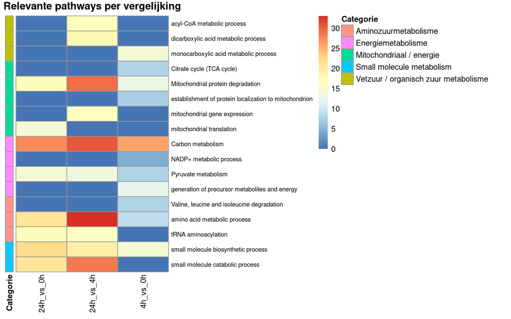

Er is duidelijk verschil te zien in de heatmap bij welke pathways waar tot expressie komen en hoe hoog. Er zijn pathways die niet bij elke vergelijking aanwezig, deze zijn gemarkeerd als 0 en opgevuld met donkerblauw. Verder heb ik categorieën gemaakt voor de pathways zodat het duidelijk is welke pathway bij welke groep hoort. Dit maakt het in het artikel ook makkelijker om te filteren op belang en welke pathway specifiek voor lipolyse is en welke bij bijvoorbeeld energiemetabolisme hoort.

Ik maak nog even een venn diagram om een mooi overzicht te krijgen welke pathway bij welke vergelijking hoort en of de pathways bij meer vergelijkingen voorkomen.

```r
pathways_4h_vs_0h <- relevante_pathways_tabel %>%
  filter(Vergelijking == "4h_vs_0h") %>%
  pull(Description) %>%
  unique()

pathways_24h_vs_0h <- relevante_pathways_tabel %>%
  filter(Vergelijking == "24h_vs_0h") %>%
  pull(Description) %>%
  unique()

pathways_24h_vs_4h <- relevante_pathways_tabel %>%
  filter(Vergelijking == "24h_vs_4h") %>%
  pull(Description) %>%
  unique()
```

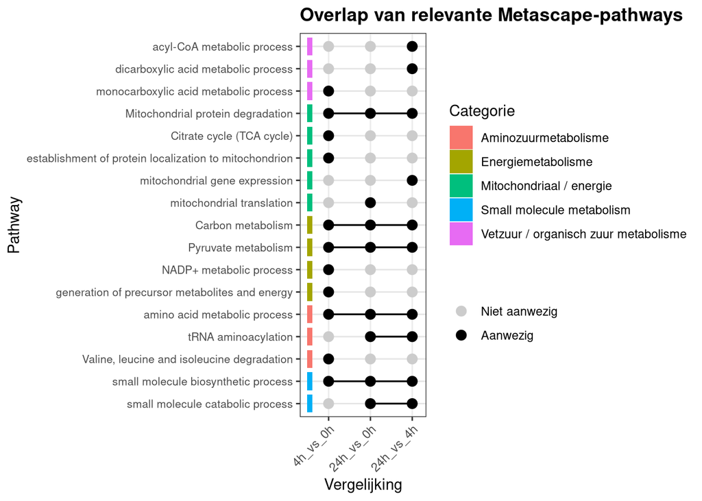

```r
pathway_overlap_plot <- relevante_pathways_tabel %>%
  mutate(
    Pathway = gsub(" - Mus musculus \\(house mouse\\)", "", Description),
    aanwezig = TRUE,
    pathway_groep = case_when(
      grepl(
        "mitochond|TCA|citrate cycle|electron transport|oxidative phosphorylation|protein localization to mitochondrion",
        Pathway,
        ignore.case = TRUE
      ) ~ "Mitochondriaal / energie",

      grepl(
        "carbon metabolism|pyruvate|precursor metabolites|NADP",
        Pathway,
        ignore.case = TRUE
      ) ~ "Energiemetabolisme",

      grepl(
        "amino acid|valine|leucine|isoleucine|tRNA aminoacylation",
        Pathway,
        ignore.case = TRUE
      ) ~ "Aminozuurmetabolisme",

      grepl(
        "acyl-CoA|dicarboxylic acid|monocarboxylic acid|fatty acid|lipid",
        Pathway,
        ignore.case = TRUE
      ) ~ "Vetzuur / organisch zuur metabolisme",

      grepl(
        "small molecule",
        Pathway,
        ignore.case = TRUE
      ) ~ "Small molecule metabolism",

      TRUE ~ "Overig"
    )
  ) %>%
  select(Pathway, pathway_groep, Vergelijking, aanwezig) %>%
  distinct()

pathway_info <- pathway_overlap_plot %>%
  distinct(Pathway, pathway_groep)

pathway_overlap_plot <- pathway_overlap_plot %>%
  select(Pathway, Vergelijking, aanwezig) %>%
  complete(
    Pathway,
    Vergelijking = c("4h_vs_0h", "24h_vs_0h", "24h_vs_4h"),
    fill = list(aanwezig = FALSE)
  ) %>%
  left_join(pathway_info, by = "Pathway") %>%
  group_by(Pathway) %>%
  mutate(
    aantal_vergelijkingen = sum(aanwezig)
  ) %>%
  ungroup() %>%
  arrange(
    factor(
      pathway_groep,
      levels = c(
        "Vetzuur / organisch zuur metabolisme",
        "Mitochondriaal / energie",
        "Energiemetabolisme",
        "Aminozuurmetabolisme",
        "Small molecule metabolism",
        "Overig"
      )
    ),
    desc(aantal_vergelijkingen),
    Pathway
  ) %>%
  mutate(
    Pathway = factor(Pathway, levels = rev(unique(Pathway))),
    Vergelijking = factor(
      Vergelijking,
      levels = c("4h_vs_0h", "24h_vs_0h", "24h_vs_4h")
    ),
    x_num = as.numeric(Vergelijking)
  )

pathway_lijnen <- pathway_overlap_plot %>%
  filter(aanwezig == TRUE) %>%
  group_by(Pathway) %>%
  summarise(
    x_start = min(x_num),
    x_end = max(x_num),
    .groups = "drop"
  ) %>%
  filter(x_start != x_end)

categorie_balk <- pathway_overlap_plot %>%
  distinct(Pathway, pathway_groep)

ggplot(pathway_overlap_plot, aes(x = x_num, y = Pathway)) +
  geom_tile(
    data = categorie_balk,
    aes(x = 0.55, y = Pathway, fill = pathway_groep),
    inherit.aes = FALSE,
    width = 0.12,
    height = 0.8
  ) +
  geom_segment(
    data = pathway_lijnen,
    aes(
      x = x_start,
      xend = x_end,
      y = Pathway,
      yend = Pathway
    ),
    inherit.aes = FALSE,
    linewidth = 0.6
  ) +
  geom_point(
    aes(color = aanwezig),
    size = 3
  ) +
  scale_x_continuous(
    breaks = c(1, 2, 3),
    labels = c("4h_vs_0h", "24h_vs_0h", "24h_vs_4h"),
    limits = c(0.45, 3.2)
  ) +
  scale_color_manual(
    values = c("FALSE" = "grey80", "TRUE" = "black"),
    labels = c("Niet aanwezig", "Aanwezig"),
    name = ""
  ) +
  labs(
    title = "Overlap van relevante Metascape-pathways",
    x = "Vergelijking",
    y = "Pathway",
    fill = "Categorie"
  ) +
  theme_bw() +
  theme(
    axis.text.x = element_text(angle = 45, hjust = 1),
    axis.text.y = element_text(size = 8),
    plot.title = element_text(face = "bold"),
    legend.position = "right",
    panel.grid.major.y = element_line(color = "grey90"),
    panel.grid.minor = element_blank()
  )
```

#### 04-06-2026

Toen ik mijn overlap grafiek en de heatmap wou verwerken in het artikel, kwam ik erachter dat ik de tijdspunten verkeerd heb geïnterpreteerd. A blijkt dus 24h te zijn in plaats van 0h en C is 0h in plaats van 24h. Wat ik nu opnieuw moet doen is de DEG-bestanden hernoemen, de inputbestanden voor Metascape opnieuw maken, Metascape opnieuw runnen en de grafieken opnieuw maken.

```r
deg_ab <- read.csv("/students/2025-2026/Thema08/lipolyse/unpacked/transcriptomics/significant_DEG_AB_rna.csv")
deg_ac <- read.csv("/students/2025-2026/Thema08/lipolyse/unpacked/transcriptomics/significant_DEG_AC_rna.csv")
deg_bc <- read.csv("/students/2025-2026/Thema08/lipolyse/unpacked/transcriptomics/significant_DEG_BC_rna.csv")


correct_deg_24h_vs_4h <- deg_ab
correct_deg_24h_vs_0h <- deg_ac
correct_deg_4h_vs_0h  <- deg_bc
```

```r
make_metascape_file <- function(dap_genes, deg_genes, output_file) {

  dap_genes <- unique(na.omit(dap_genes))
  deg_genes <- unique(na.omit(deg_genes))

  max_length <- max(length(dap_genes), length(deg_genes))

  dap_genes <- c(dap_genes, rep(NA, max_length - length(dap_genes)))
  deg_genes <- c(deg_genes, rep(NA, max_length - length(deg_genes)))

  metascape_input <- data.frame(
    DAP = dap_genes,
    DEG = deg_genes
  )

  write.csv(
    metascape_input,
    output_file,
    row.names = FALSE,
    quote = FALSE,
    na = ""
  )
}

make_metascape_file(
  dap_genes = dap_4h_vs_0h_sig$ensembl_gene_id,
  deg_genes = correct_deg_4h_vs_0h$Gene,
  output_file = "/students/2025-2026/Thema08/lipolyse/unpacked/Metascape_input/Correct_Metascape_4h_vs_0h.csv"
)

make_metascape_file(
  dap_genes = dap_24h_vs_0h_sig$ensembl_gene_id,
  deg_genes = correct_deg_24h_vs_0h$Gene,
  output_file = "/students/2025-2026/Thema08/lipolyse/unpacked/Metascape_input/Correct_Metascape_24h_vs_0h.csv"
)

make_metascape_file(
  dap_genes = dap_24h_vs_4h_sig$ensembl_gene_id,
  deg_genes = correct_deg_24h_vs_4h$Gene,
  output_file = "/students/2025-2026/Thema08/lipolyse/unpacked/Metascape_input/Correct_Metascape_24h_vs_4h.csv"
)
```

```r
metascape_files_controle <- data.frame(
  Bestand = c(
    "Metascape_4h_vs_0h.csv",
    "Metascape_24h_vs_0h.csv",
    "Metascape_24h_vs_4h.csv"
  ),
  Bestaat = c(
    file.exists("/students/2025-2026/Thema08/lipolyse/unpacked/Metascape_input/Correct_Metascape_4h_vs_0h.csv"),
    file.exists("/students/2025-2026/Thema08/lipolyse/unpacked/Metascape_input/Correct_Metascape_24h_vs_0h.csv"),
    file.exists("/students/2025-2026/Thema08/lipolyse/unpacked/Metascape_input/Correct_Metascape_24h_vs_4h.csv")
  ),
  Aantal_DAPs = c(
    length(unique(na.omit(dap_4h_vs_0h_sig$ensembl_gene_id))),
    length(unique(na.omit(dap_24h_vs_0h_sig$ensembl_gene_id))),
    length(unique(na.omit(dap_24h_vs_4h_sig$ensembl_gene_id)))
  ),
  Aantal_DEGs = c(
    length(unique(na.omit(correct_deg_4h_vs_0h$Gene))),
    length(unique(na.omit(correct_deg_24h_vs_0h$Gene))),
    length(unique(na.omit(correct_deg_24h_vs_4h$Gene)))
  )
)

knitr::kable(metascape_files_controle, row.names = FALSE)
```

| Bestand | Bestaat | Aantal_DAPs | Aantal_DEGs |
| --- | --- | --- | --- |
| Metascape_4h_vs_0h.csv | TRUE | 268 | 11603 |
| Metascape_24h_vs_0h.csv | TRUE | 999 | 11587 |
| Metascape_24h_vs_4h.csv | TRUE | 963 | 9997 |

Ik heb Metascape opnieuw uitgevoerd, en nu ga ik de resultaten opnieuw inlezen, filteren en aangepaste plots maken.

```r
metascape_4h_vs_0h_correct <- read_excel(
  "/students/2025-2026/Thema08/lipolyse/unpacked/Metascape_output/metascape_result_4hvs_0h_correct.xlsx",
  sheet = "Enrichment"
)

metascape_24h_vs_0h_correct <- read_excel(
  "/students/2025-2026/Thema08/lipolyse/unpacked/Metascape_output/metascape_result_24hvs0h_correct.xlsx",
  sheet = "Enrichment"
)

metascape_24h_vs_4h_correct <- read_excel(
  "/students/2025-2026/Thema08/lipolyse/unpacked/Metascape_output/metascape_result_24hvs4h_correct.xlsx",
  sheet = "Enrichment"
)
```

Controleren of de nieuwe bestanden goed zijn gemaakt en ingelezen

```r
metascape_check <- data.frame(
  Vergelijking = c("4h_vs_0h", "24h_vs_0h", "24h_vs_4h"),
  Aantal_rijen = c(
    nrow(metascape_4h_vs_0h_correct),
    nrow(metascape_24h_vs_0h_correct),
    nrow(metascape_24h_vs_4h_correct)
  ),
  Aantal_kolommen = c(
    ncol(metascape_4h_vs_0h_correct),
    ncol(metascape_24h_vs_0h_correct),
    ncol(metascape_24h_vs_4h_correct)
  ),
  Kolomnamen = c(
    paste(colnames(metascape_4h_vs_0h_correct), collapse = ", "),
    paste(colnames(metascape_24h_vs_0h_correct), collapse = ", "),
    paste(colnames(metascape_24h_vs_4h_correct), collapse = ", ")
  )
)

knitr::kable(metascape_check, row.names = FALSE)
```

| Vergelijking | Aantal_rijen | Aantal_kolommen | Kolomnamen |
| --- | --- | --- | --- |
| 4h_vs_0h | 502 | 9 | GroupID, Category, Term, Description, LogP, Log(q-value), Genes, Symbols, InTerm_InList |
| 24h_vs_0h | 428 | 9 | GroupID, Category, Term, Description, LogP, Log(q-value), Genes, Symbols, InTerm_InList |
| 24h_vs_4h | 374 | 9 | GroupID, Category, Term, Description, LogP, Log(q-value), Genes, Symbols, InTerm_InList |

Ze komen relatief overeen met de eerdere check voor de metascape resultaten, alleen heeft 4h_vs_0h nu 1 rij meer.

Ik ga nu weer filteren op ‘summary’ en dan de controle uitvoeren of het goed is gefilterd.

```r
metascape_summary_4h_vs_0h_correct <- metascape_4h_vs_0h_correct %>%
  filter(grepl("Summary", GroupID))

metascape_summary_24h_vs_0h_correct <- metascape_24h_vs_0h_correct %>%
  filter(grepl("Summary", GroupID))

metascape_summary_24h_vs_4h_correct <- metascape_24h_vs_4h_correct %>%
  filter(grepl("Summary", GroupID))
```

```r
summary_controle_correct <- data.frame(
  Vergelijking = c("4h_vs_0h", "24h_vs_0h", "24h_vs_4h"),
  Aantal_termen_totaal = c(
    nrow(metascape_4h_vs_0h_correct),
    nrow(metascape_24h_vs_0h_correct),
    nrow(metascape_24h_vs_4h_correct)
  ),
  Aantal_summary_termen = c(
    nrow(metascape_summary_4h_vs_0h_correct),
    nrow(metascape_summary_24h_vs_0h_correct),
    nrow(metascape_summary_24h_vs_4h_correct)
  )
)

knitr::kable(summary_controle_correct, row.names = FALSE)
```

| Vergelijking | Aantal_termen_totaal | Aantal_summary_termen |
| --- | --- | --- |
| 4h_vs_0h | 502 | 20 |
| 24h_vs_0h | 428 | 20 |
| 24h_vs_4h | 374 | 20 |

Het is opvallend dat ik nu ook weer 20 summary termen heb net als de vorige keer wanneer ik de metascape resultaten gefilterd heb op summary.

Ik ga nu gelijk filteren op de uitgebreide relevante termen lijst.

```r
metascape_summary_4h_vs_0h_uitgebreid_correct <- metascape_summary_4h_vs_0h_correct %>%
  mutate(
    relevant_thermogenese_metabolisme_uitgebreid = grepl(
      paste(uitgebreide_relevante_termen, collapse = "|"),
      Description,
      ignore.case = TRUE
    ),
    housekeeping = grepl(
      paste(housekeeping_termen, collapse = "|"),
      Description,
      ignore.case = TRUE
    )
  )

metascape_summary_24h_vs_0h_uitgebreid_correct <- metascape_summary_24h_vs_0h_correct %>%
  mutate(
    relevant_thermogenese_metabolisme_uitgebreid = grepl(
      paste(uitgebreide_relevante_termen, collapse = "|"),
      Description,
      ignore.case = TRUE
    ),
    housekeeping = grepl(
      paste(housekeeping_termen, collapse = "|"),
      Description,
      ignore.case = TRUE
    )
  )

metascape_summary_24h_vs_4h_uitgebreid_correct <- metascape_summary_24h_vs_4h_correct %>%
  mutate(
    relevant_thermogenese_metabolisme_uitgebreid = grepl(
      paste(uitgebreide_relevante_termen, collapse = "|"),
      Description,
      ignore.case = TRUE
    ),
    housekeeping = grepl(
      paste(housekeeping_termen, collapse = "|"),
      Description,
      ignore.case = TRUE
    )
  )
```

Deze lijst ga ik weer controleren of het goed uitgevoerd is.

```r
filter_controle_uitgebreid_correct <- data.frame(
  Vergelijking = c("4h_vs_0h", "24h_vs_0h", "24h_vs_4h"),
  Summary_termen = c(
    nrow(metascape_summary_4h_vs_0h_uitgebreid_correct),
    nrow(metascape_summary_24h_vs_0h_uitgebreid_correct),
    nrow(metascape_summary_24h_vs_4h_uitgebreid_correct)
  ),
  Uitgebreide_relevante_termen = c(
    sum(metascape_summary_4h_vs_0h_uitgebreid_correct$relevant_thermogenese_metabolisme_uitgebreid),
    sum(metascape_summary_24h_vs_0h_uitgebreid_correct$relevant_thermogenese_metabolisme_uitgebreid),
    sum(metascape_summary_24h_vs_4h_uitgebreid_correct$relevant_thermogenese_metabolisme_uitgebreid)
  ),
  Housekeeping_termen = c(
    sum(metascape_summary_4h_vs_0h_uitgebreid_correct$housekeeping),
    sum(metascape_summary_24h_vs_0h_uitgebreid_correct$housekeeping),
    sum(metascape_summary_24h_vs_4h_uitgebreid_correct$housekeeping)
  )
)

knitr::kable(filter_controle_uitgebreid_correct, row.names = FALSE)
```

| Vergelijking | Summary_termen | Uitgebreide_relevante_termen | Housekeeping_termen |
| --- | --- | --- | --- |
| 4h_vs_0h | 20 | 11 | 1 |
| 24h_vs_0h | 20 | 8 | 5 |
| 24h_vs_4h | 20 | 10 | 3 |

De relevante termen zijn in dit geval ook hetzelfde als de eerste keer dat ik de resultaten verwerkte. Ik ga kijken of hier ook nieuwe pathways uit zijn gekomen of dat ze hetzelfde zijn.

```r
relevante_pathways_tabel_correct <- bind_rows(
  metascape_summary_4h_vs_0h_uitgebreid_correct %>%
    filter(relevant_thermogenese_metabolisme_uitgebreid == TRUE) %>%
    mutate(Vergelijking = "4h_vs_0h"),

  metascape_summary_24h_vs_0h_uitgebreid_correct %>%
    filter(relevant_thermogenese_metabolisme_uitgebreid == TRUE) %>%
    mutate(Vergelijking = "24h_vs_0h"),

  metascape_summary_24h_vs_4h_uitgebreid_correct %>%
    filter(relevant_thermogenese_metabolisme_uitgebreid == TRUE) %>%
    mutate(Vergelijking = "24h_vs_4h")
) %>%
  select(
    Vergelijking,
    Category,
    Description,
    LogP,
    `Log(q-value)`
  ) %>%
  arrange(Vergelijking, `Log(q-value)`)

knitr::kable(relevante_pathways_tabel_correct, row.names = FALSE, digits = 3)
```

| Vergelijking | Category | Description | LogP | Log(q-value) |
| --- | --- | --- | --- | --- |
| 24h_vs_0h | KEGG Pathway | Carbon metabolism - Mus musculus (house mouse) | -30.850 | -27.747 |
| 24h_vs_0h | GO Biological Processes | small molecule biosynthetic process | -25.055 | -22.268 |
| 24h_vs_0h | GO Biological Processes | small molecule catabolic process | -23.687 | -21.051 |
| 24h_vs_0h | GO Biological Processes | amino acid metabolic process | -23.440 | -20.863 |
| 24h_vs_0h | Reactome Gene Sets | Mitochondrial protein degradation | -19.236 | -16.960 |
| 24h_vs_0h | GO Biological Processes | tRNA aminoacylation | -19.206 | -16.935 |
| 24h_vs_0h | GO Biological Processes | mitochondrial translation | -16.779 | -14.657 |
| 24h_vs_0h | KEGG Pathway | Pyruvate metabolism - Mus musculus (house mouse) | -16.528 | -14.421 |
| 24h_vs_4h | GO Biological Processes | amino acid metabolic process | -36.254 | -33.046 |
| 24h_vs_4h | KEGG Pathway | Carbon metabolism - Mus musculus (house mouse) | -33.833 | -30.698 |
| 24h_vs_4h | Reactome Gene Sets | Mitochondrial protein degradation | -32.307 | -29.262 |
| 24h_vs_4h | GO Biological Processes | small molecule catabolic process | -31.519 | -28.571 |
| 24h_vs_4h | GO Biological Processes | small molecule biosynthetic process | -21.410 | -19.268 |
| 24h_vs_4h | GO Biological Processes | dicarboxylic acid metabolic process | -19.662 | -17.571 |
| 24h_vs_4h | GO Biological Processes | acyl-CoA metabolic process | -18.600 | -16.550 |
| 24h_vs_4h | GO Biological Processes | mitochondrial gene expression | -18.459 | -16.422 |
| 24h_vs_4h | GO Biological Processes | tRNA aminoacylation | -18.151 | -16.140 |
| 24h_vs_4h | KEGG Pathway | Pyruvate metabolism - Mus musculus (house mouse) | -15.520 | -13.609 |
| 4h_vs_0h | KEGG Pathway | Carbon metabolism - Mus musculus (house mouse) | -30.650 | -26.401 |
| 4h_vs_0h | GO Biological Processes | small molecule biosynthetic process | -18.828 | -15.181 |
| 4h_vs_0h | GO Biological Processes | monocarboxylic acid metabolic process | -18.373 | -14.822 |
| 4h_vs_0h | Reactome Gene Sets | Mitochondrial protein degradation | -16.829 | -13.534 |
| 4h_vs_0h | GO Biological Processes | generation of precursor metabolites and energy | -16.002 | -12.929 |
| 4h_vs_0h | GO Biological Processes | amino acid metabolic process | -11.598 | -9.073 |
| 4h_vs_0h | KEGG Pathway | Valine, leucine and isoleucine degradation - Mus musculus (house mouse) | -10.329 | -7.932 |
| 4h_vs_0h | KEGG Pathway | Pyruvate metabolism - Mus musculus (house mouse) | -10.194 | -7.802 |
| 4h_vs_0h | KEGG Pathway | Citrate cycle (TCA cycle) - Mus musculus (house mouse) | -10.140 | -7.754 |
| 4h_vs_0h | GO Biological Processes | establishment of protein localization to mitochondrion | -9.552 | -7.211 |
| 4h_vs_0h | GO Biological Processes | NADP+ metabolic process | -6.539 | -4.543 |

Ik kan niet direct een grote verandering zien, maar misschien wordt er wel wat zichtbaar in de heatmap en/of de overlap grafiek.

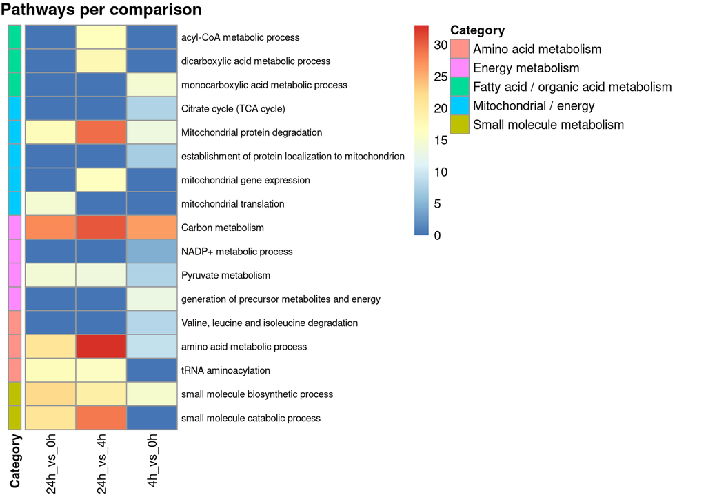

```r
heatmap_data_correct <- relevante_pathways_tabel_correct %>%
  mutate(
    enrichment_score = -`Log(q-value)`,
    Description_clean = gsub(" - Mus musculus \\(house mouse\\)", "", Description),

    pathway_groep = case_when(
      grepl(
        "mitochond|TCA|citrate cycle|electron transport|oxidative phosphorylation|protein localization to mitochondrion",
        Description_clean,
        ignore.case = TRUE
      ) ~ "Mitochondrial / energy",

      grepl(
        "carbon metabolism|pyruvate|precursor metabolites|NADP",
        Description_clean,
        ignore.case = TRUE
      ) ~ "Energy metabolism",

      grepl(
        "amino acid|valine|leucine|isoleucine|tRNA aminoacylation",
        Description_clean,
        ignore.case = TRUE
      ) ~ "Amino acid metabolism",

      grepl(
        "acyl-CoA|dicarboxylic acid|monocarboxylic acid|fatty acid|lipid",
        Description_clean,
        ignore.case = TRUE
      ) ~ "Fatty acid / organic acid metabolism",

      grepl(
        "small molecule",
        Description_clean,
        ignore.case = TRUE
      ) ~ "Small molecule metabolism",

      TRUE ~ "Other"
    )
  ) %>%
  select(Description_clean, pathway_groep, Vergelijking, enrichment_score) %>%
  pivot_wider(
    names_from = Vergelijking,
    values_from = enrichment_score,
    values_fill = 0
  ) %>%
  arrange(
    factor(
      pathway_groep,
      levels = c(
        "Fatty acid / organic acid metabolism",
        "Mitochondrial / energy",
        "Energy metabolism",
        "Amino acid metabolism",
        "Small molecule metabolism",
        "Other"
      )
    ),
    Description_clean
  )

heatmap_matrix_correct <- as.data.frame(heatmap_data_correct)
rownames(heatmap_matrix_correct) <- heatmap_matrix_correct$Description_clean

row_annotation_correct <- data.frame(
  Category = heatmap_matrix_correct$pathway_groep
)
rownames(row_annotation_correct) <- rownames(heatmap_matrix_correct)

heatmap_matrix_correct <- heatmap_matrix_correct %>%
  select(-Description_clean, -pathway_groep)

pheatmap(
  as.matrix(heatmap_matrix_correct),
  cluster_rows = FALSE,
  cluster_cols = FALSE,
  annotation_row = row_annotation_correct,
  main = "Pathways per comparison",
  angle_col = 90,
  fontsize_row = 7,
  fontsize_col = 9,
  fontsize = 9,
  treeheight_row = 0,
  treeheight_col = 0,
  legend = TRUE,
  annotation_legend = TRUE
)
```

In de heatmap is geen duidelijk verschil.

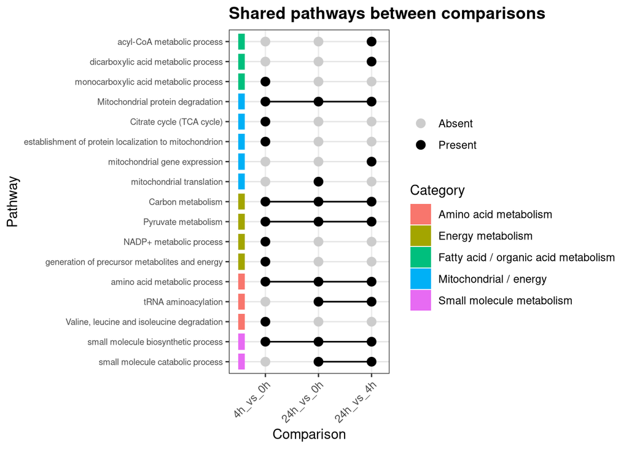

```r
pathway_overlap_plot_correct <- relevante_pathways_tabel_correct %>%
  mutate(
    Pathway = gsub(" - Mus musculus \\(house mouse\\)", "", Description),
    aanwezig = TRUE,

    pathway_groep = case_when(
      grepl(
        "mitochond|TCA|citrate cycle|electron transport|oxidative phosphorylation|protein localization to mitochondrion",
        Pathway,
        ignore.case = TRUE
      ) ~ "Mitochondrial / energy",

      grepl(
        "carbon metabolism|pyruvate|precursor metabolites|NADP",
        Pathway,
        ignore.case = TRUE
      ) ~ "Energy metabolism",

      grepl(
        "amino acid|valine|leucine|isoleucine|tRNA aminoacylation",
        Pathway,
        ignore.case = TRUE
      ) ~ "Amino acid metabolism",

      grepl(
        "acyl-CoA|dicarboxylic acid|monocarboxylic acid|fatty acid|lipid",
        Pathway,
        ignore.case = TRUE
      ) ~ "Fatty acid / organic acid metabolism",

      grepl(
        "small molecule",
        Pathway,
        ignore.case = TRUE
      ) ~ "Small molecule metabolism",

      TRUE ~ "Overig"
    )
  ) %>%
  select(Pathway, pathway_groep, Vergelijking, aanwezig) %>%
  distinct()

pathway_info <- pathway_overlap_plot_correct %>%
  distinct(Pathway, pathway_groep)

pathway_overlap_plot_correct <- pathway_overlap_plot_correct %>%
  select(Pathway, Vergelijking, aanwezig) %>%
  complete(
    Pathway,
    Vergelijking = c("4h_vs_0h", "24h_vs_0h", "24h_vs_4h"),
    fill = list(aanwezig = FALSE)
  ) %>%
  left_join(pathway_info, by = "Pathway") %>%
  group_by(Pathway) %>%
  mutate(
    aantal_vergelijkingen = sum(aanwezig)
  ) %>%
  ungroup() %>%
  arrange(
    factor(
      pathway_groep,
      levels = c(
          "Fatty acid / organic acid metabolism",
          "Mitochondrial / energy",
          "Energy metabolism",
          "Amino acid metabolism",
          "Small molecule metabolism",
          "Other"
      )
    ),
    desc(aantal_vergelijkingen),
    Pathway
  ) %>%
  mutate(
    Pathway = factor(Pathway, levels = rev(unique(Pathway))),
    Vergelijking = factor(
      Vergelijking,
      levels = c("4h_vs_0h", "24h_vs_0h", "24h_vs_4h")
    ),
    x_num = as.numeric(Vergelijking)
  )

pathway_lijnen <- pathway_overlap_plot_correct %>%
  filter(aanwezig == TRUE) %>%
  group_by(Pathway) %>%
  summarise(
    x_start = min(x_num),
    x_end = max(x_num),
    .groups = "drop"
  ) %>%
  filter(x_start != x_end)

categorie_balk_correct <- pathway_overlap_plot_correct %>%
  distinct(Pathway, pathway_groep)

ggplot(pathway_overlap_plot_correct, aes(x = x_num, y = Pathway)) +
  geom_tile(
    data = categorie_balk_correct,
    aes(x = 0.55, y = Pathway, fill = pathway_groep),
    inherit.aes = FALSE,
    width = 0.12,
    height = 0.8
  ) +
  geom_segment(
    data = pathway_lijnen,
    aes(
      x = x_start,
      xend = x_end,
      y = Pathway,
      yend = Pathway
    ),
    inherit.aes = FALSE,
    linewidth = 0.6
  ) +
  geom_point(
    aes(color = aanwezig),
    size = 3
  ) +
  scale_x_continuous(
    breaks = c(1, 2, 3),
    labels = c("4h_vs_0h", "24h_vs_0h", "24h_vs_4h"),
    limits = c(0.45, 3.2)
  ) +
  scale_color_manual(
    values = c("FALSE" = "grey80", "TRUE" = "black"),
    labels = c("Absent", "Present"),
    name = ""
  ) +
  labs(
    title = "Shared pathways between comparisons",
    x = "Comparison",
    y = "Pathway",
    fill = "Category"
  ) +
  theme_bw() +
  theme(
    axis.text.x = element_text(angle = 45, hjust = 1),
    axis.text.y = element_text(size = 7),
    plot.title = element_text(face = "bold"),
    legend.position = "right",
    panel.grid.major.y = element_line(color = "grey90"),
    panel.grid.minor = element_blank()
  )
```

Omdat hier ook geen verschil in zit ga ik de pathways 1 op 1 vergelijken of er op deze manier verschillen aanwezig zijn.

```r
cat("Aantal oude relevante pathways:", nrow(relevante_pathways_tabel), "\n")
```

```
## Aantal oude relevante pathways: 29
```

```r
cat("Aantal correcte relevante pathways:", nrow(relevante_pathways_tabel_correct), "\n\n")
```

```
## Aantal correcte relevante pathways: 29
```

```r
cat("Pathways in correct maar niet in oud:\n")
```

```
## Pathways in correct maar niet in oud:
```

```r
print(setdiff(
  paste(relevante_pathways_tabel_correct$Vergelijking,
        relevante_pathways_tabel_correct$Description),
  paste(relevante_pathways_tabel$Vergelijking,
        relevante_pathways_tabel$Description)
))
```

```
## character(0)
```

```r
cat("\nPathways in oud maar niet in correct:\n")
```

```
##
## Pathways in oud maar niet in correct:
```

```r
print(setdiff(
  paste(relevante_pathways_tabel$Vergelijking,
        relevante_pathways_tabel$Description),
  paste(relevante_pathways_tabel_correct$Vergelijking,
        relevante_pathways_tabel_correct$Description)
))
```

```
## character(0)
```

Er zijn dus geen nieuwe pathways gevonden, maar wat ik nog wel kan controleren of de LogP en Log(q-value) zijn veranderd.

```r
score_vergelijking <- relevante_pathways_tabel %>%
  rename(
    LogP_oud = LogP,
    LogQ_oud = `Log(q-value)`
  ) %>%
  inner_join(
    relevante_pathways_tabel_correct %>%
      rename(
        LogP_correct = LogP,
        LogQ_correct = `Log(q-value)`
      ),
    by = c("Vergelijking", "Category", "Description")
  ) %>%
  mutate(
    verschil_LogP = LogP_correct - LogP_oud,
    verschil_LogQ = LogQ_correct - LogQ_oud
  )

summary(score_vergelijking$verschil_LogP)
```

```
##    Min. 1st Qu.  Median    Mean 3rd Qu.    Max.
## -0.6101 -0.1783  0.0000 -0.1229  0.0000  0.0000
```

```r
summary(score_vergelijking$verschil_LogQ)
```

```
##    Min. 1st Qu.  Median    Mean 3rd Qu.    Max.
## -0.6101 -0.1722  0.0000 -0.1258  0.0000  0.0000
```

```r
knitr::kable(
  score_vergelijking %>%
    filter(verschil_LogP != 0 | verschil_LogQ != 0),
  row.names = FALSE,
  digits = 3
)
```

| Vergelijking | Category | Description | LogP_oud | LogQ_oud | LogP_correct | LogQ_correct | verschil_LogP | verschil_LogQ |
| --- | --- | --- | --- | --- | --- | --- | --- | --- |
| 4h_vs_0h | KEGG Pathway | Carbon metabolism - Mus musculus (house mouse) | -30.139 | -25.890 | -30.650 | -26.401 | -0.511 | -0.511 |
| 4h_vs_0h | GO Biological Processes | small molecule biosynthetic process | -18.255 | -14.608 | -18.828 | -15.181 | -0.574 | -0.574 |
| 4h_vs_0h | GO Biological Processes | monocarboxylic acid metabolic process | -17.762 | -14.212 | -18.373 | -14.822 | -0.610 | -0.610 |
| 4h_vs_0h | Reactome Gene Sets | Mitochondrial protein degradation | -16.548 | -13.144 | -16.829 | -13.534 | -0.281 | -0.390 |
| 4h_vs_0h | GO Biological Processes | generation of precursor metabolites and energy | -15.540 | -12.467 | -16.002 | -12.929 | -0.462 | -0.462 |
| 4h_vs_0h | GO Biological Processes | amino acid metabolic process | -11.266 | -8.741 | -11.598 | -9.073 | -0.332 | -0.332 |
| 4h_vs_0h | KEGG Pathway | Valine, leucine and isoleucine degradation - Mus musculus (house mouse) | -10.151 | -7.759 | -10.329 | -7.932 | -0.178 | -0.172 |
| 4h_vs_0h | KEGG Pathway | Pyruvate metabolism - Mus musculus (house mouse) | -10.030 | -7.645 | -10.194 | -7.802 | -0.163 | -0.157 |
| 4h_vs_0h | KEGG Pathway | Citrate cycle (TCA cycle) - Mus musculus (house mouse) | -9.992 | -7.612 | -10.140 | -7.754 | -0.148 | -0.142 |
| 4h_vs_0h | GO Biological Processes | establishment of protein localization to mitochondrion | -9.361 | -7.026 | -9.552 | -7.211 | -0.191 | -0.185 |
| 4h_vs_0h | GO Biological Processes | NADP+ metabolic process | -6.427 | -4.431 | -6.539 | -4.543 | -0.112 | -0.112 |

Hier is te zien dat er alleen verschil is gevonden in de vergelijking 4h vs 0h. Er is te zien dat de LogP en Log(q-value) licht is veranderd in vergelijking tot de LogP en Log(q-value) die de pathways hebben. Wat dit uiteindelijk betekent is dat ik wel de gecorrigeerde plots ga gebruiken in het artikel, maar in zijn geheel is er weinig veranderd.

### Referenties

Metascape is gebruikt voor de enrichment-analyse: [Metascape](https://metascape.org/gp/index.html#/main/step1)  
Beschrijving van de metascape tool: [Metascape artikel](https://pubmed.ncbi.nlm.nih.gov/30944313/)  
Lipolyse pathways: [Lipolyse pathways](https://www.frontiersin.org/journals/endocrinology/articles/10.3389/fendo.2023.1106544/full)